# Machine Learning

Research Informatics Core

Fall 2026

# 1 Day 1

**DOWNLOAD THE R SCRIPT FOR THIS WORKSHOP:**

https://wd.cri.uic.edu/machine_learning/ML_exercise.R

## 1.1 Create a dataset for machine learning

- Will use the TCGA cancer database (Demo)
- Create a dataset using breast cancer studies (Demo)
- Normalize expression (Demo)
- Filter dataset (Demo)
- Make a balanced dataset of ductal and lobular cancer types
- Make a training and testing dataset

### 1.1.1 Select cancer dataset for download (INSTRUCTOR DEMONSTRATION)

**NOTE: we will review these steps, but do not run them during the workshop. Try as a take-home exercise later.** Skip to **Normalization and filtering**.

We will obtain a large (>1000 samples) data set from TCGA that will be suitable for our machine learning data set.

```r
library(TCGAretriever)

# Obtain a list of cancer studies from cBio
all_studies <- get_cancer_studies()

# Get list of breast cancer studies
brca_studies <- all_studies[all_studies$cancerTypeId == "brca",]
nrow(brca_studies)
```

```
## [1] 27
```

```r
# Find studies with > 1000 patients
brca_studies[brca_studies$allSampleCount > 1000,c("name", "allSampleCount", "studyId")]
```

|  | name | allSampleCount | studyId |
| --- | --- | --- | --- |
| 48 | Breast Cancer (METABRIC, Nature 2012 & Nat Commun 2016) | 2509 | brca_metabric |
| 61 | Breast Invasive Carcinoma (TCGA, Firehose Legacy) | 1108 | brca_tcga |
| 327 | Invasive Breast Carcinoma (TCGA GDC, 2025) | 1102 | brca_tcga_gdc |
| 429 | Breast Cancer (MSK, Nat Genet 2025) | 3879 | breast_msk_2025 |
| 516 | Breast Invasive Carcinoma (TCGA, PanCancer Atlas) | 1084 | brca_tcga_pan_can_atlas_2018 |

```r
# Define the cancer study id: brca_tcga
my_csid <- "brca_tcga"

# Obtain genetic profiles, type of assays and data available
brca_pro <- get_genetic_profiles(csid = my_csid)
brca_pro$molecularProfileId
```

```
##  [1] "brca_tcga_gistic"
##  [2] "brca_tcga_linear_CNA"
##  [3] "brca_tcga_methylation_hm450"
##  [4] "brca_tcga_mrna"
##  [5] "brca_tcga_mrna_median_Zscores"
##  [6] "brca_tcga_mrna_median_all_sample_Zscores"
##  [7] "brca_tcga_mutations"
##  [8] "brca_tcga_phosphoprotein_quantification"
##  [9] "brca_tcga_protein_quantification"
## [10] "brca_tcga_protein_quantification_zscores"
## [11] "brca_tcga_rna_seq_v2_mrna"
## [12] "brca_tcga_rna_seq_v2_mrna_median_Zscores"
## [13] "brca_tcga_rna_seq_v2_mrna_median_all_sample_Zscores"
## [14] "brca_tcga_rppa"
## [15] "brca_tcga_rppa_Zscores"
```

```r
# Obtain cases
brca_cas <- get_case_lists(csid = my_csid)
brca_cas$sampleListId
```

```
##  [1] "brca_tcga_3way_complete"
##  [2] "brca_tcga_all"
##  [3] "brca_tcga_cna"
##  [4] "brca_tcga_cnaseq"
##  [5] "brca_tcga_methylation_all"
##  [6] "brca_tcga_methylation_hm27"
##  [7] "brca_tcga_methylation_hm450"
##  [8] "brca_tcga_mrna"
##  [9] "brca_tcga_phosphoprotein_quantification"
## [10] "brca_tcga_protein_quantification"
## [11] "brca_tcga_rna_seq_v2_mrna"
## [12] "brca_tcga_rppa"
## [13] "brca_tcga_sequenced"
```

```r
# Determine cases with mRNA data available
q_csid <- "brca_tcga"
q_cases <- "brca_tcga_rna_seq_v2_mrna"
rna_prf <- "brca_tcga_rna_seq_v2_mrna"

# Download clinical data
brca_cli <- get_clinical_data(csid = q_csid, case_list_id = q_cases)
head(colnames(brca_cli))
```

```
## [1] "sampleId"             "patientId"            "studyId"
## [4] "CANCER_TYPE"          "CANCER_TYPE_DETAILED" "DAYS_TO_COLLECTION"
```

```r
# Count cancer types
table(brca_cli$CANCER_TYPE_DETAILED)
```

```
##
##              Adenoid Cystic Breast Cancer
##                                         2
##                      Basal Cell Carcinoma
##                                         1
##                                    Breast
##                                         7
##            Breast Invasive Carcinoma, NOS
##                                         1
##          Breast Invasive Ductal Carcinoma
##                                       812
##         Breast Invasive Lobular Carcinoma
##                                       206
##  Breast Invasive Mixed Mucinous Carcinoma
##                                        16
## Breast Mixed Ductal and Lobular Carcinoma
##                                        28
##                 Invasive Breast Carcinoma
##                                         6
##   Malignant Phyllodes Tumor of the Breast
##                                         1
##                 Metaplastic Breast Cancer
##                                        14
##               Paget Disease of the Nipple
##                                         3
##   Solid Papillary Carcinoma of the Breast
##                                         2
```

Download mRNA expression (this can take several minutes).

```r
# Download mRNA expression as TPM
all_brca_RNA <- fetch_all_tcgadata(case_list_id = q_cases,
                                   gprofile_id = rna_prf,
                                   mutations = FALSE)
```

### 1.1.2 Normalization and filtering

**Start here for the workshop**

Read in the BRCA RNA-seq data set and log-transform.

```r
# Read mRNA expression data
all_brca_RNA <- readRDS(url("https://wd.cri.uic.edu/machine_learning/brca_RNA_TPM.rds"))
all_brca_RNA[1:5,1:5]
```

|  | entrezGeneId | hugoGeneSymbol | type | TCGA-3C-AAAU-01 | TCGA-3C-AALI-01 |
| --- | --- | --- | --- | --- | --- |
| 1 | 618 | BCYRN1 | ncRNA | 0.0000 | 0.0000 |
| 2 | 711 | ERC2-IT1 | ncRNA | 0.0000 | 0.0000 |
| 3 | 750 | GAS8-AS1 | ncRNA | 9.6504 | 16.3132 |
| 4 | 3262 | HPVC1 | ncRNA | 0.0000 | 0.0000 |
| 5 | 3653 | IPW | ncRNA | 102.9944 | 759.3747 |

```r
# use the gene symbol as the rownames, remove the other feature metadata
rownames(all_brca_RNA) <- all_brca_RNA$hugoGeneSymbol
all_brca_RNA <- all_brca_RNA[,-1:-3]
all_brca_RNA[1:5,1:5]
```

|  | TCGA-3C-AAAU-01 | TCGA-3C-AALI-01 | TCGA-3C-AALJ-01 | TCGA-3C-AALK-01 | TCGA-4H-AAAK-01 |
| --- | --- | --- | --- | --- | --- |
| BCYRN1 | 0.0000 | 0.0000 | 0.0000 | 0.0000 | 0.0000 |
| ERC2-IT1 | 0.0000 | 0.0000 | 0.0000 | 0.0000 | 0.0000 |
| GAS8-AS1 | 9.6504 | 16.3132 | 26.2919 | 5.7923 | 2.1277 |
| HPVC1 | 0.0000 | 0.0000 | 0.0000 | 0.0000 | 0.0000 |
| IPW | 102.9944 | 759.3747 | 39.5558 | 309.5573 | 244.4170 |

Log-scale, adding a pseudo-count.

```r
all_brca_RNA.log2 <- log2(all_brca_RNA + 1)
```

Minimum expression filter: keep only those genes expressed in at least 30% of samples with log2(TPM)>0.

```r
# Notes on this command:
#               1. Create boolean matrix based on values bigger than 0
#       2. Sum the rows: gets total number of samples with >0 expression
#                                       3. Compare to 30% of the number
#                                          of samples (total columns)
keep <- rowSums(all_brca_RNA.log2>0) >= 0.3 * ncol(all_brca_RNA.log2)
table(keep)
```

```
## keep
## FALSE  TRUE
##  2197 18146
```

```r
all_brca_RNA.log2.filtered <- all_brca_RNA.log2[keep,]
```

### 1.1.3 Make a balanced dataset

Ensure that the number of classes is balanced to avoid biasing the model.

```r
library(tidyverse)
# Read clinical data
brca_cli <- readRDS(url("https://wd.cri.uic.edu/machine_learning/brca_clinical.rds"))
# Remove samples that are missing CANCER_TYPE_DETAILED metadata
brca_cli <- subset(brca_cli, !is.na(CANCER_TYPE_DETAILED))
```

Get samples of ductal and lobular types of breast cancer.

```r
brca_cli.ductal <- brca_cli[
  brca_cli$CANCER_TYPE_DETAILED=="Breast Invasive Ductal Carcinoma",]
brca_cli.lobular <- brca_cli[
  brca_cli$CANCER_TYPE_DETAILED=="Breast Invasive Lobular Carcinoma",]
num_ductal <- nrow(brca_cli.ductal)
num_ductal
```

```
## [1] 812
```

```r
num_lobular <- nrow(brca_cli.lobular)
num_lobular
```

```
## [1] 206
```

Since number of lobular samples is less than than ductal, select a subset of ductal samples so the data set is balanced.

```r
set.seed(123)
ductal.samples <- sample(brca_cli.ductal$sampleId, num_lobular)
ductal.exp <- all_brca_RNA.log2.filtered[,ductal.samples]
lobular.samples <- brca_cli.lobular$sampleId
lobular.exp <- all_brca_RNA.log2.filtered[,lobular.samples]

# Combine ductal and lobular expression datasets
expr_combined <- cbind(ductal.exp, lobular.exp)
num_ductal <- num_lobular
labels <- c(rep("Ductal", num_ductal), rep("Lobular", num_lobular))
table(labels)
```

```
## labels
##  Ductal Lobular
##     206     206
```

```r
# Build data.frame for modeling: samples x genes
df <- as.data.frame(t(expr_combined))  # rows = samples, cols = genes
df <- tibble::rownames_to_column(df, var = "sample_id")
df$class <- factor(labels, levels = c("Ductal","Lobular"))

# Fix gene names to a format acceptable by R
colnames(df) <- make.names(colnames(df))
```

### 1.1.4 Split into training and testing cohorts

*NOTE: if you need to catch up you can read in the df variable at this point.*

```r
df <- readRDS(url("https://wd.cri.uic.edu/machine_learning/ML_df.rds"))
```

Randomly split into training data (70%) and test data (30%). Note that setting the seed here is not necessary in general but it ensures that these exercises are reproducible for the workshop.

```r
library(tidyverse)
library(caret)
set.seed(123)
train_idx <- createDataPartition(df$class, p = 0.7, list = FALSE)
train_df  <- df[train_idx, ]
test_df   <- df[-train_idx, ]

# For convenience, create x (data) and y (class labels)
x_train <- train_df %>% select(-sample_id, -class)
y_train <- train_df$class
x_test  <- test_df  %>% select(-sample_id, -class)
y_test  <- test_df$class
```

## 1.2 Feature selection

*NOTE: if you need to catch up, load the required objects from our RData file. This will populate the following variables: `x_train`, `y_train`, `x_test`, `y_test`, `Xtr`, `Xte`.*

```r
load(url("https://wd.cri.uic.edu/machine_learning/MLobjects.RData"))
```

Try two simple examples of feature selection: taking the top genes by variance and/or t-statistic.

### 1.2.1 Variance filtering of features

Compute variance per gene, and obtain the top 500 variable genes.

```r
# Compute variance per gene
gene_vars <- sort(apply(x_train, 2, var), decreasing=TRUE)
head(gene_vars)
```

```
##   CLEC3A  SCGB2A2     CPB1  SCGB1D2    GSTM1    MUCL1
## 26.53123 22.65776 21.95347 19.49457 19.36375 16.80111
```

```r
# Keep top 500 variable genes (adjust as needed)
top_var_genes <- names(gene_vars)[1:500]
df_var_filtered <- x_train[, top_var_genes]
df_var_filtered[1:5,1:5]
```

|  | CLEC3A | SCGB2A2 | CPB1 | SCGB1D2 | GSTM1 |
| --- | --- | --- | --- | --- | --- |
| 1 | 7.771852 | 9.446156 | 4.396618 | 7.212719 | 9.447453 |
| 4 | 0.000000 | 4.822863 | 11.305799 | 4.038427 | 1.621712 |
| 5 | 1.204015 | 8.224012 | 1.316146 | 6.852306 | 1.992768 |
| 6 | 0.000000 | 6.040614 | 3.123914 | 4.885325 | 1.346815 |
| 7 | 11.347685 | 9.158187 | 1.016496 | 6.171921 | 0.595981 |

### 1.2.2 T-test filtering of features

Run a t-test between Ductal and Lobular for each gene.

```r
# T-test to rank remaining features
ttest_ranks <- apply(x_train, 2, function(g) {
  t.test(g ~ y_train)$statistic
})
ttest_ranks <- sort(abs(ttest_ranks), decreasing=TRUE)
head(ttest_ranks)
```

```
##     CDH1   SOWAHA  SHROOM1   PSMD14  RAPGEF3    FXYD1
## 14.18417 10.54356 10.37435 10.14770 10.11638 10.02037
```

Pick the top 100 genes by their t-statistic.

```r
# Pick the top 100 genes
top_ttest_genes <- names(ttest_ranks)[1:100]
df_ttest_filtered <- x_train[, top_ttest_genes]
df_ttest_filtered[1:5,1:5]
```

|  | CDH1 | SOWAHA | SHROOM1 | PSMD14 | RAPGEF3 |
| --- | --- | --- | --- | --- | --- |
| 1 | 12.25291 | 3.319965 | 10.222974 | 10.00057 | 7.961152 |
| 4 | 13.92266 | 3.718910 | 4.539630 | 10.35016 | 6.706837 |
| 5 | 12.00711 | 2.296105 | 5.441792 | 10.89618 | 6.362014 |
| 6 | 13.17085 | 2.280600 | 6.618253 | 10.84798 | 7.220431 |
| 7 | 14.28970 | 2.348261 | 5.787116 | 10.76371 | 7.703081 |

## 1.3 Logistic regression model with RFE

Use recursive feature elimination (RFE) to select the most informative features for a logistic regression model. For this we will start with the top 100 genes from the t-test filtering, and then filter down further with RFE.

```r
library(caret)
library(ggplot2)

# RFE setup
rfe_ctrl <- rfeControl(functions = lrFuncs,
                   method = "cv", # cross validation
                   number = 10) # number of folds

# Number of features to be retained in the updated model
sizes <- c(5, 10, 15, 20, 25, 30, 35, 40, 45, 50)

# Run RFE
set.seed(123)
rfe_results <- rfe(
  x = df_ttest_filtered,
  y = y_train,
  sizes = sizes,
  rfeControl = rfe_ctrl
)

rfe_results
```

```
##
## Recursive feature selection
##
## Outer resampling method: Cross-Validated (10 fold)
##
## Resampling performance over subset size:
##
##  Variables Accuracy  Kappa AccuracySD KappaSD Selected
##          5   0.8456 0.6904    0.06982  0.1400
##         10   0.8515 0.7025    0.05713  0.1145        *
##         15   0.8384 0.6767    0.07279  0.1453
##         20   0.8316 0.6634    0.07688  0.1535
##         25   0.8279 0.6557    0.05252  0.1046
##         30   0.8312 0.6626    0.07850  0.1561
##         35   0.8039 0.6079    0.06765  0.1344
##         40   0.7871 0.5739    0.08075  0.1621
##         45   0.8107 0.6214    0.05576  0.1107
##         50   0.7872 0.5747    0.09307  0.1857
##        100   0.7446 0.4892    0.10013  0.1995
##
## The top 5 variables (out of 10):
##    CDH1, SOWAHA, TAMALIN, SRSF5, LTBP4
```

```r
# Get best features
best_rfe_feats <- predictors(rfe_results)
best_rfe_feats
```

```
##  [1] "CDH1"     "SOWAHA"   "TAMALIN"  "SRSF5"    "LTBP4"    "LCN6"
##  [7] "CALCOCO1" "KANK3"    "TDRD10"   "D2HGDH"
```

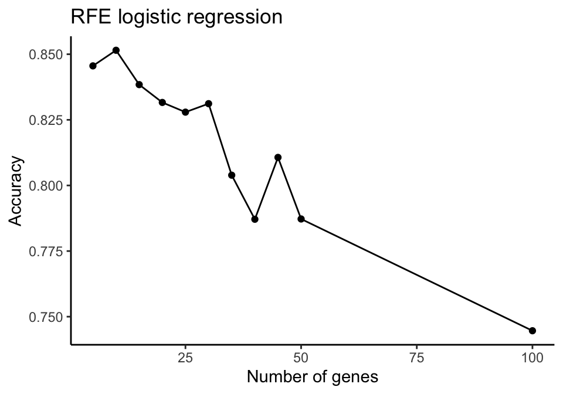

```r
# Plot RFE results
rfe_results_df <- rfe_results$results

ggplot(rfe_results_df, aes(x = Variables, y = Accuracy)) +
  geom_line() +
  geom_point() +
  labs(y = "Accuracy", x = "Number of genes", title = "RFE logistic regression") +
  theme_classic()
```

```r
# Make training and testing datasets using best features
Xtr <- x_train[, best_rfe_feats]
Xte <- x_test[, best_rfe_feats]
```

## 1.4 Test cohort and cross-validation with LR, confusion matrix, ROC/AUC

*NOTE: if you need to catch up, load the required objects from our RData file. This will populate the following variables: `x_train`, `y_train`, `x_test`, `y_test`, `Xtr`, `Xte`.*

```r
load(url("https://wd.cri.uic.edu/machine_learning/MLobjects.RData"))
```

Run cross-validation and train the logistic regression model.

```r
library(caret)
library(ggplot2)
library(pROC)

# Define cross-validation
lr_ctrl <- trainControl(
  method = "cv",
  number = 10,              # 10-fold CV
  classProbs = TRUE,
  summaryFunction = twoClassSummary, # Report ROC, Sensitivity, and Specificity
  savePredictions = "final"  # keep CV predictions
)

set.seed(123)
# Train logistic regression
lr_model <- train(
  x = Xtr,
  y = y_train,
  method = "glm",
  family = "binomial",
  trControl = lr_ctrl,
  metric = "ROC"
)
lr_model # CV results summary
```

```
## Generalized Linear Model
##
## 290 samples
##  10 predictor
##   2 classes: 'Ductal', 'Lobular'
##
## No pre-processing
## Resampling: Cross-Validated (10 fold)
## Summary of sample sizes: 260, 261, 261, 262, 261, 261, ...
## Resampling results:
##
##   ROC        Sens       Spec
##   0.9428277  0.8747619  0.8847619
```

Inspect the predictions from the model and evaluate.

```r
# Cross-validation predictions
lr_train_preds <- lr_model$pred$pred
lr_train_obs <- lr_model$pred$obs

# Make prediction table of training data
lr_train_pred_table <- table(Predicted = lr_train_preds, Actual = lr_train_obs)
lr_train_pred_table
```

```
##          Actual
## Predicted Ductal Lobular
##   Ductal     127      17
##   Lobular     18     128
```

```r
# Make confusion matrix for model on training data cross-validation
confusionMatrix(lr_train_preds, lr_train_obs, positive = "Lobular")
```

```
## Confusion Matrix and Statistics
##
##           Reference
## Prediction Ductal Lobular
##    Ductal     127      17
##    Lobular     18     128
##
##                Accuracy : 0.8793
##                  95% CI : (0.8362, 0.9145)
##     No Information Rate : 0.5
##     P-Value [Acc > NIR] : <2e-16
##
##                   Kappa : 0.7586
##
##  Mcnemar's Test P-Value : 1
##
##             Sensitivity : 0.8828
##             Specificity : 0.8759
##          Pos Pred Value : 0.8767
##          Neg Pred Value : 0.8819
##              Prevalence : 0.5000
##          Detection Rate : 0.4414
##    Detection Prevalence : 0.5034
##       Balanced Accuracy : 0.8793
##
##        'Positive' Class : Lobular
##
```

```r
# Make test set predictions
lr_test_preds <- predict(lr_model, newdata = Xte)
head(lr_test_preds)
```

```
## [1] Ductal  Ductal  Ductal  Ductal  Ductal  Lobular
## Levels: Ductal Lobular
```

```r
# Make prediction table of testing data
lr_test_pred_table <- table(Predicted = lr_test_preds, Actual = y_test)
lr_test_pred_table
```

```
##          Actual
## Predicted Ductal Lobular
##   Ductal      57       8
##   Lobular      4      53
```

```r
# Make confusion matrix for model on testing data
confusionMatrix(lr_test_preds, y_test, positive = "Lobular")
```

```
## Confusion Matrix and Statistics
##
##           Reference
## Prediction Ductal Lobular
##    Ductal      57       8
##    Lobular      4      53
##
##                Accuracy : 0.9016
##                  95% CI : (0.8345, 0.9481)
##     No Information Rate : 0.5
##     P-Value [Acc > NIR] : <2e-16
##
##                   Kappa : 0.8033
##
##  Mcnemar's Test P-Value : 0.3865
##
##             Sensitivity : 0.8689
##             Specificity : 0.9344
##          Pos Pred Value : 0.9298
##          Neg Pred Value : 0.8769
##              Prevalence : 0.5000
##          Detection Rate : 0.4344
##    Detection Prevalence : 0.4672
##       Balanced Accuracy : 0.9016
##
##        'Positive' Class : Lobular
##
```

```r
# Calculate the ROC curve
prob_pred <- predict(lr_model, newdata = Xte, type = "prob")$Lobular
head(prob_pred)
```

```
## [1] 0.179989442 0.271200004 0.123590336 0.020214130 0.002743686 0.579122973
```

```r
lr_roc <- roc(response = y_test, predictor = prob_pred)
lr_auc <- auc(lr_roc)
lr_auc
```

```
## Area under the curve: 0.9637
```

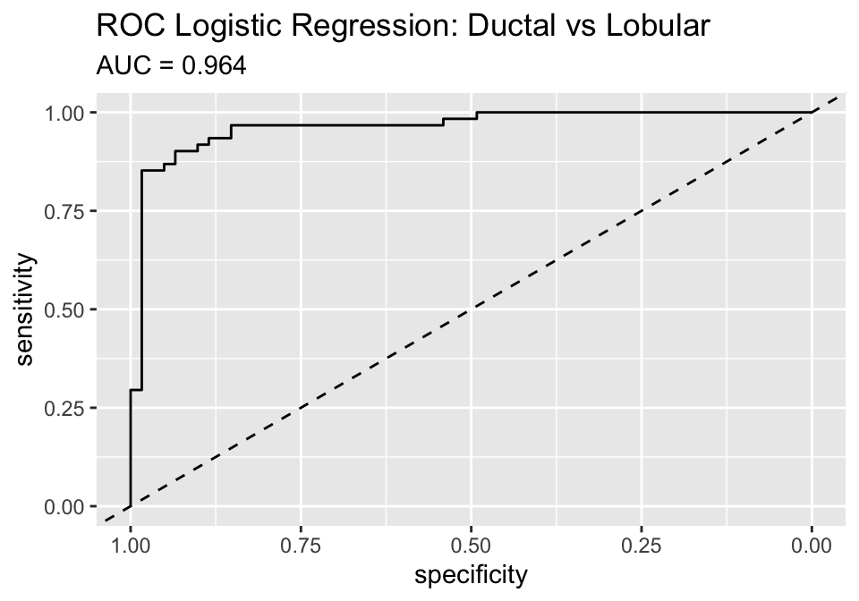

```r
# Plotting the ROC curve with ggroc
ggroc(lr_roc) +
  geom_abline(intercept=1, slope=1, linetype="dashed") +
  labs(title="ROC Logistic Regression: Ductal vs Lobular",
    subtitle=paste0("AUC = ", round(lr_auc, 3)))
```

# 2 Day 2

## 2.1 Train an SVM model using the same predictors

*NOTE: if you need to catch up, load the required objects from our RData file. This will populate the following variables: `x_train`, `y_train`, `x_test`, `y_test`, `Xtr`, `Xte`. Also load the libraries.*

```r
library(caret)
library(ggplot2)
library(pROC)
load(url("https://wd.cri.uic.edu/machine_learning/MLobjects.RData"))
```

Train the SVM model.

- Note that in practice you may want to choose a larger grid for tuning `C`.
- If using a radial or polynomial kernel, you would also want to tune `gamma`.

```r
library(kernlab)
svm_ctrl <- trainControl(
  method = "cv",   # cross-validation
  number = 10,     # 10-fold CV
  classProbs = TRUE,
  summaryFunction = twoClassSummary, # Report ROC, Sensitivity, and Specificity
  savePredictions = "final"  # keep CV predictions
)

set.seed(123)
svm_model <- train(
  y_train ~ .,
  data = data.frame(y_train, Xtr),
  method = "svmLinear",
  trControl = svm_ctrl,
  tuneGrid = expand.grid(C = c(0.1, 1, 10)),
  metric = "ROC"
)
svm_model
```

```
## Support Vector Machines with Linear Kernel
##
## 290 samples
##  10 predictor
##   2 classes: 'Ductal', 'Lobular'
##
## No pre-processing
## Resampling: Cross-Validated (10 fold)
## Summary of sample sizes: 260, 261, 261, 262, 261, 261, ...
## Resampling results across tuning parameters:
##
##   C     ROC        Sens       Spec
##    0.1  0.9384422  0.8952381  0.8566667
##    1.0  0.9417438  0.9023810  0.8495238
##   10.0  0.9408889  0.8952381  0.8495238
##
## ROC was used to select the optimal model using the largest value.
## The final value used for the model was C = 1.
```

Evaluate the model.

```r
# Test predictions
svm_probs <- predict(svm_model, newdata = Xte, type = "prob")
head(svm_probs)
```

|  | Ductal | Lobular |
| --- | --- | --- |
| 1 | 0.6619967 | 0.33800334 |
| 2 | 0.7039072 | 0.29609280 |
| 3 | 0.7904251 | 0.20957486 |
| 4 | 0.9552540 | 0.04474598 |
| 5 | 0.9833773 | 0.01662270 |
| 6 | 0.3992180 | 0.60078203 |

```r
svm_preds <- predict(svm_model, newdata = Xte)
head(svm_preds)
```

```
## [1] Ductal  Ductal  Ductal  Ductal  Ductal  Lobular
## Levels: Ductal Lobular
```

```r
table(svm_preds)
```

```
## svm_preds
##  Ductal Lobular
##      66      56
```

```r
accuracy <- mean(svm_preds == y_test)
accuracy
```

```
## [1] 0.9098361
```

```r
# ROC/AUC
svm_roc <- roc(response = y_test, predictor = svm_probs$Lobular)
svm_auc <- auc(svm_roc)
svm_auc
```

```
## Area under the curve: 0.9637
```

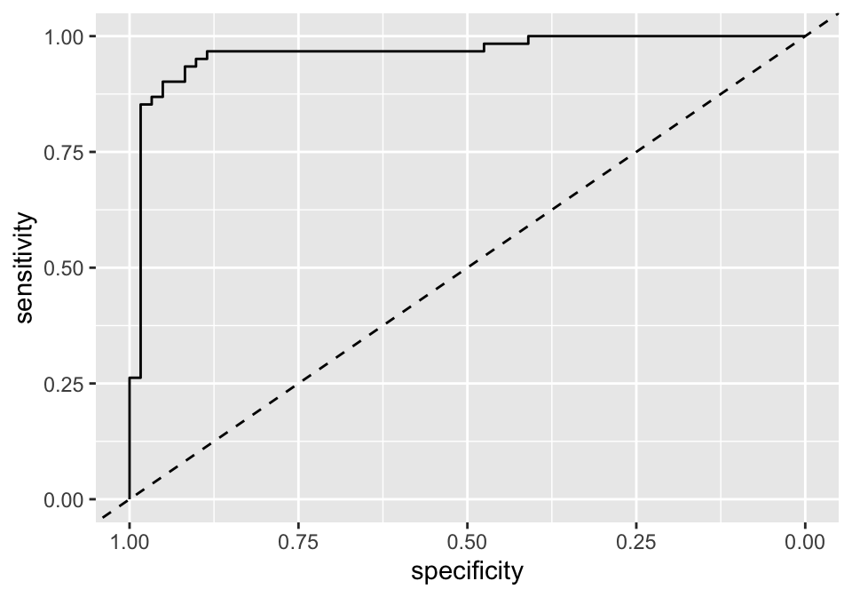

```r
# Plotting the ROC curve with ggroc
ggroc(svm_roc) +
  geom_abline(intercept=1, slope=1, linetype="dashed")
```

### 2.1.1 Comparison of two models

Compare the logistic regression and SVM models, using the class prediction probabilities for Lobular.

We can formally test if one model is significantly better than the other with a Wilcoxon signed-rank test.

```r
# recall the performance of each model from cross validation
lr_model$results$ROC
```

```
## [1] 0.9428277
```

```r
max(svm_model$results$ROC)
```

```
## [1] 0.9417438
```

```r
# use the probabilities for each model
logistic_lob <- prob_pred
svm_lob <- svm_probs[,"Lobular"]
head(logistic_lob)
```

```
## [1] 0.179989442 0.271200004 0.123590336 0.020214130 0.002743686 0.579122973
```

```r
head(svm_lob)
```

```
## [1] 0.33800334 0.29609280 0.20957486 0.04474598 0.01662270 0.60078203
```

```r
# set paired=T for the signed rank test
wilcox.test(logistic_lob, svm_lob, paired=T)
```

```
##
##  Wilcoxon signed rank test with continuity correction
##
## data:  logistic_lob and svm_lob
## V = 2945, p-value = 0.03946
## alternative hypothesis: true location shift is not equal to 0
```

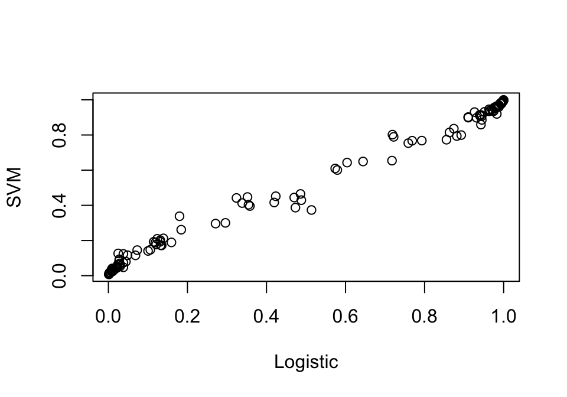

```r
# compare in a scatterplot
plot_df <- data.frame(Logistic=logistic_lob, SVM=svm_lob)
# basic R scatterplot
plot(plot_df)
```

## 2.2 Train a neural net model with regularization

*NOTE: if you need to catch up, load the required objects from our RData file. This will populate the following variables: `x_train`, `y_train`, `x_test`, `y_test`, `Xtr`, `Xte`. Also load the libraries.*

```r
library(caret)
library(ggplot2)
library(pROC)
load(url("https://wd.cri.uic.edu/machine_learning/MLobjects.RData"))
```

Train neural net with caret.

- Running a hyperparameter grid search over size and decay parameters.
- With 3 values for each of two parameters, so this will test 9 total parameter combinations.

```r
nn_ctrl <- trainControl(
  method = "cv",
  number = 10,
  classProbs = TRUE,
  summaryFunction = twoClassSummary,
  savePredictions = "final"
)

set.seed(123)
nn_model <- train(
  y_train ~ .,
  data = data.frame(y_train, Xtr),
  method = "nnet",
  trControl = nn_ctrl,
  metric = "ROC",
  tuneGrid = expand.grid(
    size = c(3, 5, 7),   # hidden layer sizes to try
    decay = c(0.001, 0.01, 0.1)  # regularization values
  ),
  trace = FALSE,
  maxit = 500
)
nn_model
```

```
## Neural Network
##
## 290 samples
##  10 predictor
##   2 classes: 'Ductal', 'Lobular'
##
## No pre-processing
## Resampling: Cross-Validated (10 fold)
## Summary of sample sizes: 260, 261, 261, 262, 261, 261, ...
## Resampling results across tuning parameters:
##
##   size  decay  ROC        Sens       Spec
##   3     0.001  0.9179297  0.8747619  0.8423810
##   3     0.010  0.9136236  0.8685714  0.8500000
##   3     0.100  0.9405465  0.8680952  0.8633333
##   5     0.001  0.8735635  0.8619048  0.7761905
##   5     0.010  0.9023968  0.8347619  0.8280952
##   5     0.100  0.9134558  0.8542857  0.8495238
##   7     0.001  0.8808050  0.8204762  0.8557143
##   7     0.010  0.8940113  0.7847619  0.8290476
##   7     0.100  0.9272857  0.8533333  0.8642857
##
## ROC was used to select the optimal model using the largest value.
## The final values used for the model were size = 3 and decay = 0.1.
```

Evaluate model accuracy.

```r
# Predict on test set
nn_probs <- predict(nn_model, newdata = Xte, type = "prob")
head(nn_probs)
```

|  | Ductal | Lobular |
| --- | --- | --- |
| 2 | 0.9194720 | 0.08052801 |
| 3 | 0.8557589 | 0.14424109 |
| 10 | 0.9591987 | 0.04080130 |
| 11 | 0.9868847 | 0.01311527 |
| 15 | 0.9653137 | 0.03468631 |
| 18 | 0.2974166 | 0.70258341 |

```r
nn_preds <- predict(nn_model, newdata = Xte)
head(nn_preds)
```

```
## [1] Ductal  Ductal  Ductal  Ductal  Ductal  Lobular
## Levels: Ductal Lobular
```

```r
table(nn_preds)
```

```
## nn_preds
##  Ductal Lobular
##      59      63
```

```r
nn_accuracy <- mean(nn_preds == y_test)
nn_accuracy
```

```
## [1] 0.8852459
```

```r
# ROC/AUC
nn_roc <- roc(response = y_test, predictor = nn_probs$Lobular)
nn_auc <- auc(nn_roc)
nn_auc
```

```
## Area under the curve: 0.9573
```

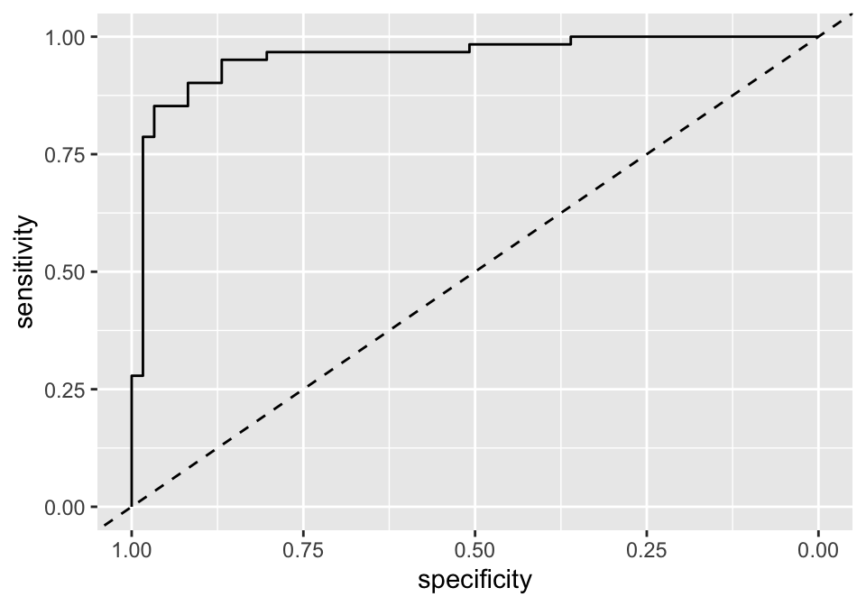

```r
# Plotting the ROC curve with ggroc
ggroc(nn_roc) +
  geom_abline(intercept=1, slope=1, linetype="dashed")
```

## 2.3 Implement a random forest and a XGBoost model

*NOTE: if you need to catch up, load the required objects from our RData file. This will populate the following variables: `x_train`, `y_train`, `x_test`, `y_test`, `Xtr`, `Xte`. Also load the libraries.*

```r
library(caret)
library(ggplot2)
library(pROC)
load(url("https://wd.cri.uic.edu/machine_learning/MLobjects.RData"))
```

### 2.3.1 Random forest

Train the random forest model.

```r
rf_ctrl <- trainControl(
  method = "cv",
  number = 10,
  classProbs = TRUE,
  summaryFunction = twoClassSummary,
  savePredictions = "final"
  )

set.seed(123)
rf_model <- train(
  y_train ~ .,
  data = data.frame(y_train, Xtr),
  method = "rf",
  trControl = rf_ctrl,
  metric = "ROC",
  tuneGrid = expand.grid(mtry = c(2,5))  # number of variables randomly sampled at each split
)
rf_model
```

```
## Random Forest
##
## 290 samples
##  10 predictor
##   2 classes: 'Ductal', 'Lobular'
##
## No pre-processing
## Resampling: Cross-Validated (10 fold)
## Summary of sample sizes: 260, 261, 261, 262, 261, 261, ...
## Resampling results across tuning parameters:
##
##   mtry  ROC        Sens       Spec
##   2     0.9301769  0.8676190  0.8566667
##   5     0.9409637  0.8814286  0.8428571
##
## ROC was used to select the optimal model using the largest value.
## The final value used for the model was mtry = 5.
```

Evaluate performance.

```r
# Predict on test set
rf_probs <- predict(rf_model, newdata = Xte, type = "prob")
head(rf_probs)
```

|  | Ductal | Lobular |
| --- | --- | --- |
| 2 | 0.890 | 0.110 |
| 3 | 0.874 | 0.126 |
| 10 | 0.650 | 0.350 |
| 11 | 0.932 | 0.068 |
| 15 | 0.974 | 0.026 |
| 18 | 0.468 | 0.532 |

```r
rf_preds <- predict(rf_model, newdata = Xte)
head(rf_preds)
```

```
## [1] Ductal  Ductal  Ductal  Ductal  Ductal  Lobular
## Levels: Ductal Lobular
```

```r
table(rf_preds)
```

```
## rf_preds
##  Ductal Lobular
##      63      59
```

```r
rf_accuracy <- mean(rf_preds == y_test)
rf_accuracy
```

```
## [1] 0.9180328
```

```r
# ROC/AUC
rf_roc <- roc(response = y_test, predictor = rf_probs$Lobular)
rf_auc <- auc(rf_roc)
rf_auc
```

```
## Area under the curve: 0.9715
```

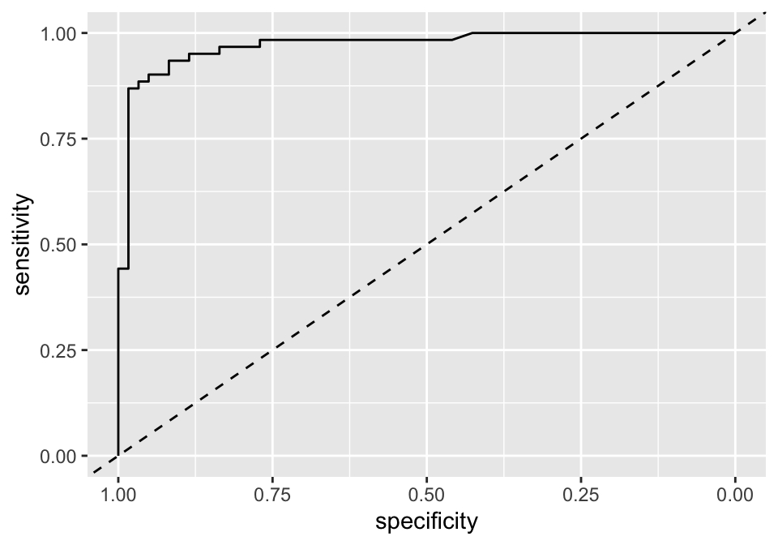

```r
# Plotting the ROC curve with ggroc
ggroc(rf_roc) +
  geom_abline(intercept=1, slope=1, linetype="dashed")
```

### 2.3.2 XGBoost model

Train XGB model.

```r
library(caret)
library(pROC)
xgb_ctrl <- trainControl(
  method = "cv",
  number = 10,
  classProbs = TRUE,
  summaryFunction = twoClassSummary,
  savePredictions = "final",
  verboseIter = FALSE
)

set.seed(123)
xgb_model <- train(
  y_train ~ .,
  data = data.frame(y_train, Xtr),
  method = "xgbTree",
  trControl = xgb_ctrl,
  metric = "ROC",
  tuneGrid = expand.grid(
    nrounds = c(50, 100),    # The total number of trees built sequentially
    max_depth = c(2, 3, 4), # maximum depth of a tree
    eta = c(0.05, 0.1, 0.3), # learning rate, shrinkage
    gamma = 0, # pruning parameter: 0 -> tree keeps splitting as long as it reduces error
    colsample_bytree = 1, # Fraction of features randomly chosen to build each tree
    min_child_weight = 1, # Controls the minimum amount of data needed in a leaf node
    subsample = 1 # Fraction of training data sampled for growing each tree
  ),
  verbosity = 0     # hides xgboost internal warnings
)
xgb_model
```

```
## eXtreme Gradient Boosting
##
## 290 samples
##  10 predictor
##   2 classes: 'Ductal', 'Lobular'
##
## No pre-processing
## Resampling: Cross-Validated (10 fold)
## Summary of sample sizes: 260, 261, 261, 262, 261, 261, ...
## Resampling results across tuning parameters:
##
##   eta   max_depth  nrounds  ROC        Sens       Spec
##   0.05  2           50      0.9454671  0.8880952  0.8357143
##   0.05  2          100      0.9436689  0.8814286  0.8500000
##   0.05  3           50      0.9342472  0.8885714  0.8290476
##   0.05  3          100      0.9366236  0.8814286  0.8290476
##   0.05  4           50      0.9365896  0.8742857  0.8500000
##   0.05  4          100      0.9345533  0.8671429  0.8285714
##   0.10  2           50      0.9436712  0.8742857  0.8495238
##   0.10  2          100      0.9409456  0.8876190  0.8428571
##   0.10  3           50      0.9374172  0.8742857  0.8290476
##   0.10  3          100      0.9374082  0.8671429  0.8223810
##   0.10  4           50      0.9344195  0.8742857  0.8223810
##   0.10  4          100      0.9319048  0.8676190  0.8290476
##   0.30  2           50      0.9297143  0.8666667  0.8357143
##   0.30  2          100      0.9259932  0.8676190  0.8423810
##   0.30  3           50      0.9250317  0.8676190  0.8290476
##   0.30  3          100      0.9225646  0.8604762  0.8290476
##   0.30  4           50      0.9338435  0.8604762  0.8428571
##   0.30  4          100      0.9283197  0.8533333  0.8566667
##
## Tuning parameter 'gamma' was held constant at a value of 0
## Tuning
##
## Tuning parameter 'min_child_weight' was held constant at a value of 1
##
## Tuning parameter 'subsample' was held constant at a value of 1
## ROC was used to select the optimal model using the largest value.
## The final values used for the model were nrounds = 50, max_depth = 2, eta
##  = 0.05, gamma = 0, colsample_bytree = 1, min_child_weight = 1 and subsample
##  = 1.
```

Evaluate model.

```r
xgb_probs <- predict(xgb_model, newdata = Xte, type = "prob")
head(xgb_probs)
```

|  | Ductal | Lobular |
| --- | --- | --- |
| 1 | 0.8395194 | 0.16048062 |
| 2 | 0.7877496 | 0.21225041 |
| 3 | 0.7384779 | 0.26152211 |
| 4 | 0.8692050 | 0.13079500 |
| 5 | 0.9202685 | 0.07973152 |
| 6 | 0.6402609 | 0.35973912 |

```r
xgb_preds <- predict(xgb_model, newdata = Xte)
head(xgb_preds)
```

```
## [1] Ductal Ductal Ductal Ductal Ductal Ductal
## Levels: Ductal Lobular
```

```r
table(xgb_preds)
```

```
## xgb_preds
##  Ductal Lobular
##      61      61
```

```r
xgb_accuracy <- mean(xgb_preds == y_test)
xgb_accuracy
```

```
## [1] 0.9180328
```

```r
# ROC/AUC
xgb_roc <- roc(response = y_test, predictor = xgb_probs$Lobular)
xgb_auc <- auc(xgb_roc)
xgb_auc
```

```
## Area under the curve: 0.9694
```

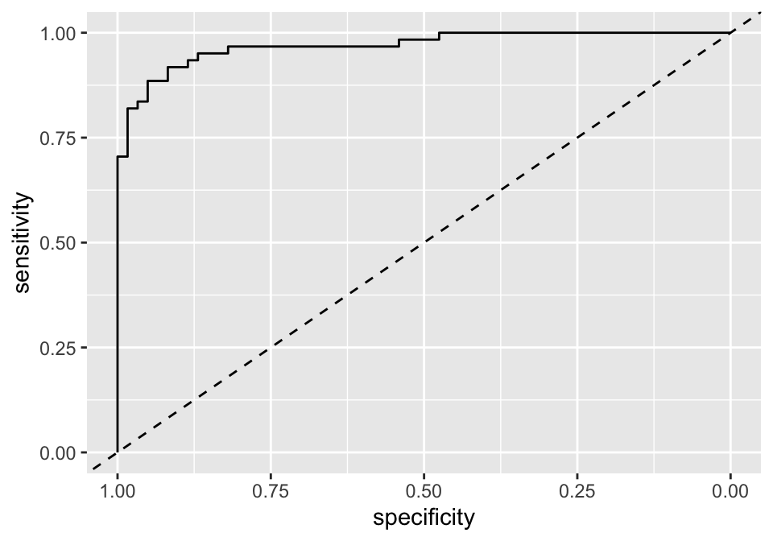

```r
# Plotting the ROC curve with ggroc
ggroc(xgb_roc) +
  geom_abline(intercept=1, slope=1, linetype="dashed")
```

## 2.4 Feature importance

We have now trained four different classifiers of ductal versus lobular breast cancer on the same ten genes. A natural question is which of those genes each model actually relies on. This is called feature importance, and it serves two purposes: interpreting a model, and selecting features for a new one.

*NOTE: this section uses the models trained in the previous sections (`lr_model`, `svm_model`, `rf_model`, `xgb_model`) together with `Xtr`, `Xte`, `y_train`, `y_test`, and the 100-gene training set `df_ttest_filtered` from Day 1. If you need to catch up, load the RData file, rerun the t-test filtering chunk from Day 1, and rerun the model training chunks above (each takes under a minute).*

```r
library(caret)
library(ggplot2)
library(pROC)
load(url("https://wd.cri.uic.edu/machine_learning/MLobjects.RData"))
```

### 2.4.1 Model-specific importance

Most model types come with their own definition of importance, built from how the model was fit:

- **Logistic regression:** the size of each coefficient’s test statistic. A gene with a large coefficient relative to its standard error matters more to the model.
- **Random forest:** the mean decrease in Gini impurity. Every time a tree splits on a gene, the split makes the resulting groups purer; the importance of a gene is the total purity gain from all splits that used it, averaged over the trees.
- **XGBoost:** gain, the average improvement in the objective from splits on that gene, which is the boosting equivalent of the random forest measure.

The `varImp` function in caret knows how to extract each of these. By default it rescales the values so the top feature is 100, which makes different models easier to compare.

```r
library(caret)
library(ggplot2)
imp_lr  <- varImp(lr_model)$importance
imp_rf  <- varImp(rf_model)$importance
imp_xgb <- varImp(xgb_model)$importance
head(imp_lr)
```

|  | Overall |
| --- | --- |
| CDH1 | 100.000000 |
| SOWAHA | 74.311338 |
| TAMALIN | 33.202712 |
| SRSF5 | 6.038576 |
| LTBP4 | 0.000000 |
| LCN6 | 17.760057 |

```r
head(imp_rf)
```

|  | Overall |
| --- | --- |
| CDH1 | 100.000000 |
| SOWAHA | 29.303301 |
| TAMALIN | 0.000000 |
| SRSF5 | 11.925131 |
| LTBP4 | 15.740600 |
| LCN6 | 2.529663 |

```r
head(imp_xgb)
```

|  | Overall |
| --- | --- |
| CDH1 | 100.000000 |
| SOWAHA | 33.856125 |
| LTBP4 | 16.529295 |
| CALCOCO1 | 14.553837 |
| D2HGDH | 10.361205 |
| SRSF5 | 6.143026 |

Put the three sets of importances in one data frame and plot them side by side.

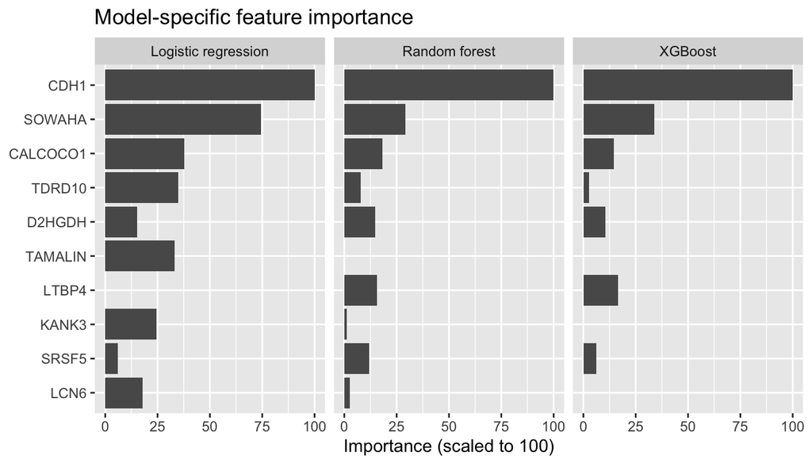

```r
imp_all <- rbind(
  data.frame(Gene = rownames(imp_lr), Importance = imp_lr$Overall,
             Model = "Logistic regression"),
  data.frame(Gene = rownames(imp_rf), Importance = imp_rf$Overall,
             Model = "Random forest"),
  data.frame(Gene = rownames(imp_xgb), Importance = imp_xgb$Overall,
             Model = "XGBoost")
)
# Order the genes by their mean importance across the three models
gene_order <- names(sort(tapply(imp_all$Importance, imp_all$Gene, mean)))
imp_all$Gene <- factor(imp_all$Gene, levels = gene_order)

ggplot(imp_all, aes(x = Gene, y = Importance)) +
  geom_col() +
  coord_flip() +
  facet_wrap(~ Model) +
  labs(title = "Model-specific feature importance",
       y = "Importance (scaled to 100)", x = NULL)
```

Some observations:

- The models agree on the top gene. CDH1 encodes E-cadherin, and loss of E-cadherin is the defining molecular feature of lobular carcinoma, so this is biologically expected.
- Below the top gene, the rankings differ. Each model measures a different thing: a coefficient in a linear model, purity gain in trees. There is no single “true” importance of a gene, only importance to a particular model.
- Because of the rescaling, the least important gene in each panel is always shown as 0. That does not mean the model ignores it, only that it ranks last. Call `varImp(model, scale = FALSE)` to see the raw values.
- The SVM is missing from this plot. A linear SVM has coefficients like logistic regression, but caret does not expose a model-specific importance for it. If you call `varImp(svm_model)`, caret silently falls back to a univariate filter (the AUC of each gene on its own), which says nothing about the model. Always check what `varImp` is actually reporting.

### 2.4.2 Permutation importance

Model-specific measures are hard to compare across model types, and they are computed on the training data. A model-agnostic alternative is permutation importance:

1. Measure the model’s performance on the test set.
2. Shuffle the values of one feature across the samples, which breaks its relationship with the outcome while keeping its distribution.
3. Measure performance again. The drop is the importance of that feature.
4. Repeat for every feature, and repeat the shuffling several times to average out randomness.

This works for any model, because it only needs predictions, and it measures what the model uses on held-out data.

```r
library(pROC)
perm_importance <- function(model, x, y, n_rep = 10) {
  # AUC with the real data
  base_auc <- as.numeric(auc(roc(y, predict(model, x, type = "prob")$Lobular,
                                 quiet = TRUE)))
  # For each gene, shuffle it and measure the drop in AUC
  sapply(colnames(x), function(g) {
    drops <- replicate(n_rep, {
      x_perm <- x
      x_perm[[g]] <- sample(x_perm[[g]])
      perm_auc <- as.numeric(auc(roc(y, predict(model, x_perm, type = "prob")$Lobular,
                                     quiet = TRUE)))
      base_auc - perm_auc
    })
    mean(drops)
  })
}

set.seed(123)
perm_lr  <- perm_importance(lr_model,  Xte, y_test)
perm_svm <- perm_importance(svm_model, Xte, y_test)
perm_rf  <- perm_importance(rf_model,  Xte, y_test)
perm_xgb <- perm_importance(xgb_model, Xte, y_test)
round(sort(perm_rf, decreasing = TRUE), 3)
```

```
##     CDH1   SOWAHA    LTBP4 CALCOCO1   TDRD10   D2HGDH    SRSF5  TAMALIN
##    0.182    0.014    0.007    0.007    0.006    0.005    0.003    0.001
##    KANK3     LCN6
##    0.001   -0.001
```

Plot the permutation importance for all four models on a common scale.

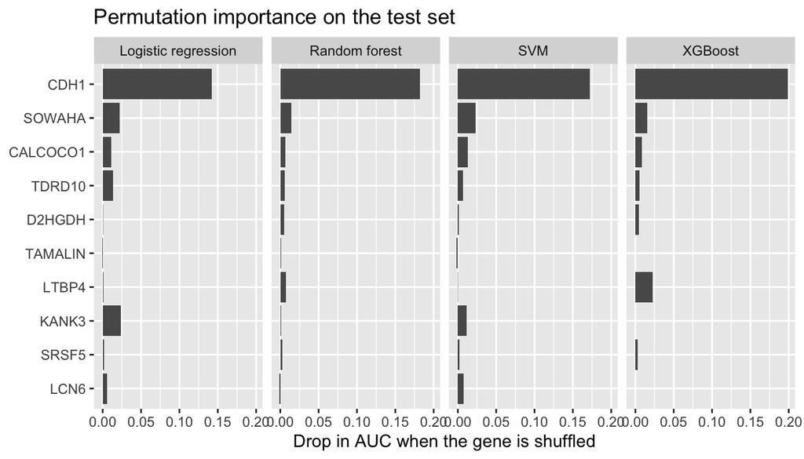

```r
perm_all <- rbind(
  data.frame(Gene = names(perm_lr),  AUC_drop = perm_lr,  Model = "Logistic regression"),
  data.frame(Gene = names(perm_svm), AUC_drop = perm_svm, Model = "SVM"),
  data.frame(Gene = names(perm_rf),  AUC_drop = perm_rf,  Model = "Random forest"),
  data.frame(Gene = names(perm_xgb), AUC_drop = perm_xgb, Model = "XGBoost")
)
perm_all$Gene <- factor(perm_all$Gene, levels = gene_order)

ggplot(perm_all, aes(x = Gene, y = AUC_drop)) +
  geom_col() +
  coord_flip() +
  facet_wrap(~ Model, nrow = 1) +
  labs(title = "Permutation importance on the test set",
       y = "Drop in AUC when the gene is shuffled", x = NULL)
```

Points to notice:

- The y-axis is now the same quantity for every model, a drop in test AUC, so the panels can be compared directly.
- A gene with importance near zero can be removed without hurting the model, at least when the others are present.
- Permutation importance can be shared between correlated genes. If two genes carry the same information, shuffling one lets the model fall back on the other, so both look unimportant even though removing both would hurt. Keep this in mind with gene expression data, where co-regulated genes are common.

### 2.4.3 Importance as feature selection

On Day 1 we selected the ten genes with recursive feature elimination and logistic regression. Feature importance offers a different route: train a model on a larger set of genes and keep the ones it finds most useful. Here we train a random forest on the 100 t-test genes from Day 1 and take its top ten.

```r
set.seed(123)
rf_100 <- train(
  x = df_ttest_filtered,
  y = y_train,
  method = "rf",
  trControl = rf_ctrl,
  metric = "ROC",
  tuneGrid = expand.grid(mtry = 10)
)
imp_100 <- varImp(rf_100)$importance
imp_100 <- imp_100[order(-imp_100$Overall), , drop = FALSE]
head(imp_100, 10)
```

|  | Overall |
| --- | --- |
| CDH1 | 100.00000 |
| BTG2 | 23.46160 |
| RAPGEF3 | 22.13797 |
| SOWAHA | 19.09486 |
| VILL | 18.44599 |
| AARS1 | 17.77390 |
| SHROOM1 | 16.41197 |
| TNS2 | 15.12576 |
| PLAC9 | 13.90520 |
| CASP12 | 13.14004 |

```r
rf_top10 <- rownames(imp_100)[1:10]

# How many of the random forest's top 10 did RFE also choose?
intersect(rf_top10, best_rfe_feats)
```

```
## [1] "CDH1"   "SOWAHA"
```

```r
setdiff(rf_top10, best_rfe_feats)
```

```
## [1] "BTG2"    "RAPGEF3" "VILL"    "AARS1"   "SHROOM1" "TNS2"    "PLAC9"
## [8] "CASP12"
```

Train a logistic regression on the random forest’s ten genes and compare it with the RFE-based model on the test set.

```r
set.seed(123)
lr_model_rf10 <- train(
  x = x_train[, rf_top10],
  y = y_train,
  method = "glm",
  family = "binomial",
  trControl = lr_ctrl,
  metric = "ROC"
)
prob_rf10 <- predict(lr_model_rf10, newdata = x_test[, rf_top10], type = "prob")$Lobular
auc_rf10 <- auc(roc(response = y_test, predictor = prob_rf10, quiet = TRUE))

# RFE-selected genes (from Day 1) versus random forest-selected genes
data.frame(Selection = c("RFE + logistic regression", "Random forest importance"),
           Test_AUC = round(c(as.numeric(lr_auc), as.numeric(auc_rf10)), 3))
```

| Selection | Test_AUC |
| --- | --- |
| RFE + logistic regression | 0.964 |
| Random forest importance | 0.970 |

The two selection methods overlap only partly, yet both produce good classifiers. With hundreds of correlated genes there are many gene sets that separate the classes about equally well, and which one you get depends on the method. This is why a list of “important genes” from a single model should be read as one adequate description of the data, not the only one.

## 2.5 Ridge regression model for Age

Using the same TCGA breast cancer study as before, but this time we are looking to predict age. DNA methylation is known to change with age in a consistent way (this is the basis of “epigenetic clocks”), so we will use the DNA methylation data from the same study as our predictors.

### 2.5.1 Download DNA methylation data (INSTRUCTOR DEMONSTRATION)

**NOTE: we will review these steps, but do not run them during the workshop.** The download takes a long time because cBioPortal returns methylation one gene at a time. We provide a pre-downloaded copy below.

The TCGA breast cancer study includes DNA methylation measured on the Illumina HumanMethylation450 (HM450) array. cBioPortal reports one beta value per gene (the fraction of methylated DNA at the promoter probe, from 0 to 1).

```r
library(TCGAretriever)

# The molecular profiles for the study include a methylation profile
brca_pro <- get_genetic_profiles(csid = "brca_tcga")
brca_pro[brca_pro$molecularAlterationType == "METHYLATION", "molecularProfileId"]

# Case list of samples with HM450 methylation data
brca_cas <- get_case_lists(csid = "brca_tcga")
brca_cas[grepl("HM450", brca_cas$name), c("sampleListId", "description")]

# Download methylation beta values for all genes (this takes a long time)
all_brca_meth <- fetch_all_tcgadata(case_list_id = "brca_tcga_methylation_hm450",
                                    gprofile_id = "brca_tcga_methylation_hm450",
                                    mutations = FALSE)
```

### 2.5.2 Read in the methylation data

Read in the pre-downloaded methylation data set, along with the clinical data. The methylation data set can also be downloaded directly from:

https://wd.cri.uic.edu/machine_learning/brca_methylation_hm450.rds

```r
all_brca_meth <- readRDS(url(
  "https://wd.cri.uic.edu/machine_learning/brca_methylation_hm450.rds"))
brca_cli <- readRDS(url("https://wd.cri.uic.edu/machine_learning/brca_clinical.rds"))
all_brca_meth[1:5,1:5]
```

|  | entrezGeneId | hugoGeneSymbol | type | TCGA-3C-AAAU-01 | TCGA-3C-AALI-01 |
| --- | --- | --- | --- | --- | --- |
| 1 | 6654 | SOS1 |  | 0.0200 | 0.0156 |
| 2 | 6655 | SOS2 |  | 0.0443 | 0.0246 |
| 3 | 10978 | CLP1 |  | 0.0821 | 0.1364 |
| 4 | 64326 | COP1 |  | 0.0339 | 0.0324 |
| 5 | 750 | GAS8-AS1 | ncRNA | 0.8865 | 0.8618 |

```r
dim(all_brca_meth)
```

```
## [1] 16133   791
```

The format is the same as the expression data: one row per gene, one column per sample, plus three columns of gene metadata. Use the gene symbol as the row names and drop the metadata columns.

```r
rownames(all_brca_meth) <- all_brca_meth$hugoGeneSymbol
all_brca_meth <- as.matrix(all_brca_meth[,-1:-3])
all_brca_meth[1:5,1:5]
```

```
##          TCGA-3C-AAAU-01 TCGA-3C-AALI-01 TCGA-3C-AALJ-01 TCGA-3C-AALK-01
## SOS1              0.0200          0.0156          0.0174          0.0198
## SOS2              0.0443          0.0246          0.0338          0.0282
## CLP1              0.0821          0.1364          0.2539          0.0945
## COP1              0.0339          0.0324          0.0247          0.0261
## GAS8-AS1          0.8865          0.8618          0.8770          0.8871
##          TCGA-4H-AAAK-01
## SOS1              0.0166
## SOS2              0.0259
## CLP1              0.1171
## COP1              0.0256
## GAS8-AS1          0.8494
```

### 2.5.3 Preprocess the methylation data

A small number of genes have missing values in some samples. Remove any gene with a missing value.

```r
keep <- rowSums(is.na(all_brca_meth)) == 0
table(keep)
```

```
## keep
## FALSE  TRUE
##  1463 14670
```

```r
all_brca_meth <- all_brca_meth[keep,]
```

Beta values are bounded between 0 and 1, which compresses differences near the extremes. A common transformation for modeling is the M-value, `log2(beta / (1 - beta))`, which is unbounded and closer to normally distributed.

```r
range(all_brca_meth)
```

```
## [1] 0.0031 0.9962
```

```r
all_brca_meth.M <- log2(all_brca_meth / (1 - all_brca_meth))
range(all_brca_meth.M)
```

```
## [1] -8.329037  8.034292
```

Create a matrix where samples are in the rows, columns are the genes.

- Fix gene names to avoid dashes or other characters R does not like in naming.
- Match the samples to the clinical data by sample ID. Unlike the expression data, the methylation samples are not in the same order as the clinical table, so we cannot just copy the `AGE` column.
- Remove samples with missing age.

```r
library(glmnet)
library(caret)
library(ggplot2)
meth.data <- t(all_brca_meth.M)
colnames(meth.data) <- make.names(colnames(meth.data))
# look up the age for each methylation sample
meth_age <- brca_cli$AGE[match(rownames(meth.data), brca_cli$sampleId)]
keep <- !is.na(meth_age)
table(keep)
```

```
## keep
## FALSE  TRUE
##     4   784
```

```r
meth_age <- meth_age[keep]
meth_age.data <- meth.data[keep, ]
dim(meth_age.data)
```

```
## [1]   784 14670
```

Feature selection: top variable genes. Ridge regression handles many correlated predictors well, so we can afford to keep more features than we did for classification.

```r
meth.gene_vars <- apply(meth_age.data, 2, var)
meth.top_var_genes <- names(sort(meth.gene_vars, decreasing = TRUE))[1:5000]
meth.df.var_filt <- meth_age.data[, meth.top_var_genes]
```

```r
# make training and test sets
set.seed(123)
age_idx  <- createDataPartition(meth_age, p = 0.7, list = F)
age_x_train  <- meth.df.var_filt[age_idx, ]
age_y_train <- meth_age[age_idx]
age_x_test   <- meth.df.var_filt[-age_idx, ]
age_y_test <- meth_age[-age_idx]
```

Do a Ridge linear regression with CV.

- First determine an optimal value of lambda. `cv.glmnet` will automatically test over a range of values.
- Fit the model with the optimal choice.
- Peek at the coefficients from the model.

```r
set.seed(123)
cvfit <- cv.glmnet(age_x_train, age_y_train,
                   family = "gaussian", # regression with MSE
                   alpha = 0,   # Ridge,
                   nfolds = 5)  # 5-fold CV
best_lambda <- cvfit$lambda.min
best_lambda
```

```
## [1] 44.48517
```

```r
lin_model <- glmnet(age_x_train, age_y_train, alpha = 0, lambda = best_lambda)
# Coefficients
head(lin_model$beta)
```

```
## 6 x 1 sparse Matrix of class "dgCMatrix"
##                    s0
## SHISA3   0.0002412008
## TFAP2B  -0.0121525368
## CLCN1    0.0085619123
## CLIP4   -0.0133073641
## SLC35F1  0.0120040379
## STK33   -0.0154643570
```

The cross-validation results also give us an estimate of performance on the training data. The mean cross-validated error at the best lambda, relative to the variance of age, gives a cross-validated R².

```r
cv_mse <- cvfit$cvm[cvfit$lambda == best_lambda]
r2_cv <- 1 - cv_mse / var(age_y_train)
r2_cv
```

```
## [1] 0.4517602
```

Run predictions on the test set and evaluate error.

```r
# Predictions
preds_lin <- predict(lin_model, newx = age_x_test)

# Performance (R², RMSE)
r2_lin <- cor(preds_lin, age_y_test)^2
r2_lin
```

```
##         [,1]
## s0 0.3313926
```

```r
rmse_lin <- sqrt(mean((preds_lin - age_y_test)^2))
rmse_lin
```

```
## [1] 10.31993
```

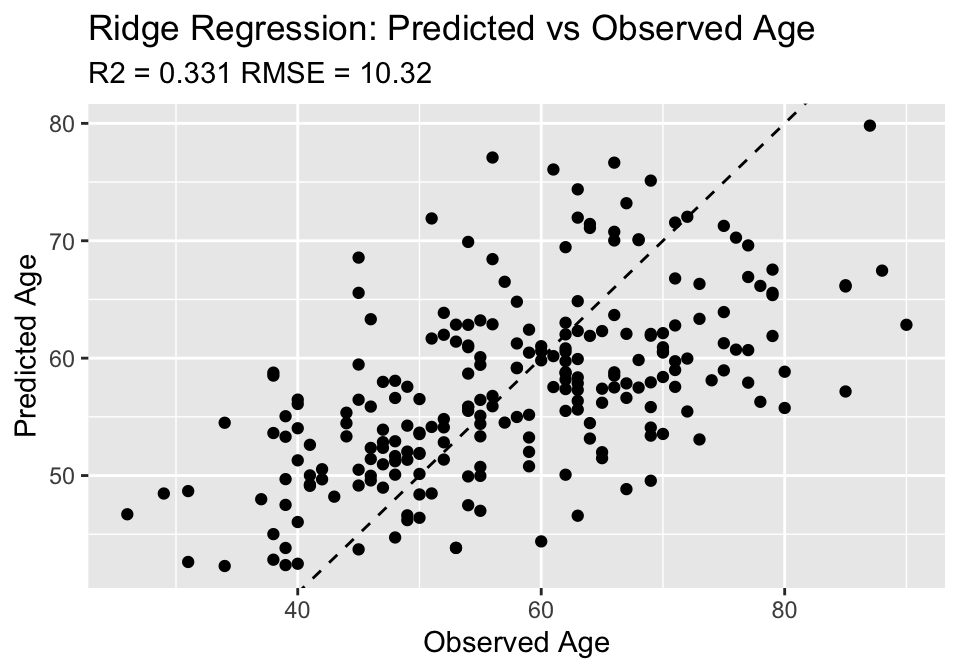

```r
# Make a plot of regression
df_pred_ridge <- data.frame(
  Observed = age_y_test,
  Predicted = as.numeric(preds_lin)
)

# Scatter plot with 1:1 line
metrics_ridge <- paste0("R2 = ", round(r2_lin, 3),
                       " RMSE = ", round(rmse_lin, 2))
ggplot(df_pred_ridge, aes(x = Observed, y = Predicted)) +
  geom_point() +
  geom_abline(intercept=0, slope=1, linetype="dashed") +
  labs(title = "Ridge Regression: Predicted vs Observed Age",
    subtitle = metrics_ridge,
    x = "Observed Age",
    y = "Predicted Age")
```

The model captures some of the age signal, with a typical error of about 10 years, but it is far from the precision of published epigenetic clocks. Two things limit us here:

- cBioPortal summarizes methylation to one value per gene, using the promoter probe that best anti-correlates with expression. The CpG sites that track age most closely are often not those probes. Working from the full array of about 450,000 probes would allow selecting the age-informative sites directly.
- These are tumor samples. Cancer disrupts methylation patterns, which adds noise relative to the normal tissue used to build most epigenetic clocks.

Note also that the cross-validated R² on the training data is higher than the test-set R². With a few hundred samples, a single random split can give an optimistic or pessimistic view of performance. Repeating the split several times, or reporting the cross-validation estimate, gives a more stable picture.

### 2.5.4 Going further: probe-level methylation and normal tissue

The gene-level summary from cBioPortal hides most of the age signal. The HM450 array measures about 485,000 individual CpG sites (probes), and epigenetic clocks are built from specific probes rather than gene summaries. UCSC Xena hosts the full probe-level matrix for the TCGA breast cancer study as a single file. It also includes about 100 samples of adjacent normal breast tissue from the same patients, which cBioPortal does not include.

#### 2.5.4.1 Obtaining and filtering the probe-level data (INSTRUCTOR DEMONSTRATION)

**NOTE: we will review these steps, but do not run them during the workshop.** The file is about 780 MB compressed and needs roughly 4 GB of memory to load. We provide the filtered result below.

**Where the data comes from.** UCSC Xena (https://xenabrowser.net) hosts merged data matrices for every TCGA cohort, one file per data type, which is far more convenient than downloading per-sample files from the GDC. To find a data set, open the Xena browser, choose a cohort such as “TCGA Breast Cancer (BRCA)”, and browse the available data types. The one we use here is:

- **Data set:** TCGA breast invasive carcinoma (BRCA) DNA methylation (HumanMethylation450), Xena ID `TCGA.BRCA.sampleMap/HumanMethylation450`.
- **Source:** TCGA Level 3 beta values from the Johns Hopkins University and University of Southern California genome characterization center, downloaded from the TCGA Data Coordinating Center and processed by UCSC into the Xena repository. This is the older TCGA “legacy” processing rather than the current GDC harmonized pipeline, so values may differ slightly from a fresh GDC download.
- **Version:** processed 2017-09-08. Beta values from 0 to 1, with probes mapped to hg19.
- **Samples:** primary tumors and, although the Xena summary lists only tumor samples, 96 adjacent normal tissue samples identifiable by their TCGA sample type code.

Download the probe-level matrix and the clinical data, and identify the tumor and adjacent normal samples. TCGA sample IDs end in a code for the sample type: `01` is primary tumor and `11` is adjacent normal tissue. The first 12 characters identify the patient, which lets us look up the age of the normal samples in the clinical table.

```r
library(data.table)
library(caret)

# Download the probe-level HM450 matrix for TCGA BRCA from UCSC Xena (~780 MB)
xena_url <- "https://tcga.xenahubs.net/download/TCGA.BRCA.sampleMap/HumanMethylation450.gz"
download.file(xena_url, "brca_hm450_probes.tsv.gz")

# Clinical data (the same file used throughout the workshop)
brca_cli <- readRDS(url("https://wd.cri.uic.edu/machine_learning/brca_clinical.rds"))

# Read only the header to get the sample IDs
hm450_samples <- colnames(fread("brca_hm450_probes.tsv.gz", nrows = 0))[-1]

# Sample type from the last two characters, patient from the first 12
tissue <- ifelse(grepl("-01$", hm450_samples), "Tumor",
          ifelse(grepl("-11$", hm450_samples), "Normal", NA))
patient <- substr(hm450_samples, 1, 12)
age <- brca_cli$AGE[match(patient, substr(brca_cli$sampleId, 1, 12))]

# Keep tumor and normal samples from patients with a recorded age
keep_samples <- !is.na(tissue) & !is.na(age)
hm450_samples <- hm450_samples[keep_samples]
sample_table <- data.frame(sampleId = hm450_samples,
                           patientId = patient[keep_samples],
                           tissue = tissue[keep_samples],
                           AGE = age[keep_samples])
table(sample_table$tissue)

# Read the matrix for those samples only: one row per probe, one column per sample
hm450 <- fread("brca_hm450_probes.tsv.gz", select = c("sample", hm450_samples))
beta <- as.matrix(hm450[, -1])
rownames(beta) <- hm450$sample
rm(hm450)
dim(beta)
```

Filter the probes.

- Remove any probe with a missing value in any sample.
- Keep only CpG probes (IDs starting with `cg`). The array also carries `rs` probes, which genotype SNPs for sample identity checks, and `ch` probes for non-CpG methylation. The `rs` probes are highly variable between people for reasons unrelated to methylation, so they must not be used as features.

```r
keep_probes <- rowSums(is.na(beta)) == 0 & grepl("^cg", rownames(beta))
table(keep_probes)
beta <- beta[keep_probes, ]
```

Select the features to keep. Three sets are combined:

1. The 10,000 most variable probes across all samples. This is unsupervised, so it does not use age.
2. The 2,000 probes most correlated with age in the tumor **training** samples. We use the same `set.seed(123)` split that the exercise uses, so the test samples never inform feature selection.
3. The probes from Horvath’s 2013 epigenetic clock, an external list that does not depend on our data at all. The coefficients are in Additional file 3 of the paper.

```r
# 1. Top 10,000 variable probes, all samples
probe_vars <- apply(beta, 1, var)
top_var_probes <- names(sort(probe_vars, decreasing = TRUE))[1:10000]

# 2. Top 2,000 age-correlated probes in the tumor training split only
is_tumor <- sample_table$tissue == "Tumor"
tumor_age <- sample_table$AGE[is_tumor]
set.seed(123)
tumor_idx <- createDataPartition(tumor_age, p = 0.7, list = FALSE)
tumor_train_beta <- beta[, is_tumor][, tumor_idx]
probe_age_cor <- cor(t(tumor_train_beta), tumor_age[tumor_idx])[, 1]
top_cor_probes <- names(sort(abs(probe_age_cor), decreasing = TRUE))[1:2000]

# 3. Horvath 2013 clock probes and coefficients (Genome Biology 14:R115, Additional file 3)
horvath_url <- paste0("https://static-content.springer.com/esm/",
  "art%3A10.1186%2Fgb-2013-14-10-r115/MediaObjects/13059_2013_3156_MOESM3_ESM.csv")
horvath <- read.csv(horvath_url, skip = 2)
horvath_intercept <- horvath$CoefficientTraining[horvath$CpGmarker == "(Intercept)"]
horvath <- horvath[grepl("^cg", horvath$CpGmarker), c("CpGmarker", "CoefficientTraining")]
names(horvath) <- c("probe", "coefficient")
# 47 of the 353 clock probes have missing values in this data set and were removed above
horvath <- horvath[horvath$probe %in% rownames(beta), ]
nrow(horvath)

# Combine the three sets
selected_probes <- unique(c(top_var_probes, top_cor_probes, horvath$probe))
length(selected_probes)
probe_table <- data.frame(probe = selected_probes,
                          top_variable = selected_probes %in% top_var_probes,
                          tumor_age_correlated = selected_probes %in% top_cor_probes,
                          horvath_clock = selected_probes %in% horvath$probe)
```

Save everything the exercise needs as one R list.

```r
meth_probes <- list(
  beta = beta[selected_probes, ],
  samples = sample_table,
  probes = probe_table,
  horvath = list(intercept = horvath_intercept, coefficients = horvath)
)
saveRDS(meth_probes, "brca_methylation_hm450_probes.rds")
```

#### 2.5.4.2 Read in the filtered probe-level data

Read in the filtered data. It is an R list holding the beta value matrix, a sample table, a probe table, and the Horvath clock coefficients. The filtered probe-level data set can also be downloaded directly from:

https://wd.cri.uic.edu/machine_learning/brca_methylation_hm450_probes.rds

```r
meth_probes <- readRDS(url(
  "https://wd.cri.uic.edu/machine_learning/brca_methylation_hm450_probes.rds"))
names(meth_probes)
```

```
## [1] "beta"    "samples" "probes"  "horvath"
```

```r
dim(meth_probes$beta)
```

```
## [1] 11884   875
```

```r
meth_probes$beta[1:5,1:4]
```

```
##            TCGA-3C-AALK-01 TCGA-AC-A5EH-01 TCGA-EW-A2FW-01 TCGA-E9-A1R0-01
## cg16620382          0.7233          0.6292          0.5404          0.1243
## cg27363327          0.6480          0.6453          0.1550          0.1220
## cg11738485          0.6132          0.9733          0.7903          0.5180
## cg01682111          0.5699          0.6387          0.9275          0.6609
## cg27260772          0.0568          0.0535          0.0394          0.0831
```

```r
head(meth_probes$samples)
```

|  | sampleId | patientId | tissue | AGE |
| --- | --- | --- | --- | --- |
| 1 | TCGA-3C-AALK-01 | TCGA-3C-AALK | Tumor | 52 |
| 2 | TCGA-AC-A5EH-01 | TCGA-AC-A5EH | Tumor | 76 |
| 3 | TCGA-EW-A2FW-01 | TCGA-EW-A2FW | Tumor | 52 |
| 4 | TCGA-E9-A1R0-01 | TCGA-E9-A1R0 | Tumor | 58 |
| 5 | TCGA-AR-A1AJ-01 | TCGA-AR-A1AJ | Tumor | 83 |
| 6 | TCGA-AC-A62Y-01 | TCGA-AC-A62Y | Tumor | 79 |

```r
table(meth_probes$samples$tissue)
```

```
##
## Normal  Tumor
##     96    779
```

```r
head(meth_probes$probes)
```

|  | probe | top_variable | tumor_age_correlated | horvath_clock |
| --- | --- | --- | --- | --- |
| 1 | cg16620382 | TRUE | FALSE | FALSE |
| 2 | cg27363327 | TRUE | FALSE | FALSE |
| 3 | cg11738485 | TRUE | FALSE | FALSE |
| 4 | cg01682111 | TRUE | FALSE | FALSE |
| 5 | cg27260772 | TRUE | FALSE | FALSE |
| 6 | cg17463633 | TRUE | FALSE | FALSE |

Set up the matrix with samples in the rows and probes in the columns. This time the age and tissue type come with the data set, already matched to the sample order.

```r
probe.data <- t(meth_probes$beta)
probe_meta <- meth_probes$samples
dim(probe.data)
```

```
## [1]   875 11884
```

#### 2.5.4.3 Ridge regression in tumor samples

Repeat the ridge regression using the tumor samples, now with probe-level data. We use the full set of filtered probes as features.

```r
is_tumor <- probe_meta$tissue == "Tumor"
tumor.data <- probe.data[is_tumor, ]
tumor_age <- probe_meta$AGE[is_tumor]

set.seed(123)
tumor_idx <- createDataPartition(tumor_age, p = 0.7, list = F)
tumor_x_train <- tumor.data[tumor_idx, ]
tumor_y_train <- tumor_age[tumor_idx]
tumor_x_test <- tumor.data[-tumor_idx, ]
tumor_y_test <- tumor_age[-tumor_idx]

set.seed(123)
tumor_cvfit <- cv.glmnet(tumor_x_train, tumor_y_train, alpha = 0, nfolds = 5)
tumor_model <- glmnet(tumor_x_train, tumor_y_train, alpha = 0,
                      lambda = tumor_cvfit$lambda.min)
preds_tumor <- predict(tumor_model, newx = tumor_x_test)
r2_tumor <- cor(preds_tumor, tumor_y_test)^2
r2_tumor
```

```
##         [,1]
## s0 0.5077326
```

```r
rmse_tumor <- sqrt(mean((preds_tumor - tumor_y_test)^2))
rmse_tumor
```

```
## [1] 9.368384
```

Probe-level data improves the fit over the gene-level summary, but the model still explains only about half of the variance in age. We will plot it next to the normal tissue result below.

#### 2.5.4.4 Ridge regression in adjacent normal tissue

Now fit the same model using only the adjacent normal samples. There are far fewer of them, so the test set is small, but the difference is striking.

```r
is_normal <- probe_meta$tissue == "Normal"
normal.data <- probe.data[is_normal, ]
normal_age <- probe_meta$AGE[is_normal]
length(normal_age)
```

```
## [1] 96
```

```r
set.seed(123)
normal_idx <- createDataPartition(normal_age, p = 0.7, list = F)
normal_x_train <- normal.data[normal_idx, ]
normal_y_train <- normal_age[normal_idx]
normal_x_test <- normal.data[-normal_idx, ]
normal_y_test <- normal_age[-normal_idx]

set.seed(123)
normal_cvfit <- cv.glmnet(normal_x_train, normal_y_train, alpha = 0, nfolds = 5)
normal_model <- glmnet(normal_x_train, normal_y_train, alpha = 0,
                       lambda = normal_cvfit$lambda.min)
preds_normal <- predict(normal_model, newx = normal_x_test)
r2_normal <- cor(preds_normal, normal_y_test)^2
r2_normal
```

```
##        [,1]
## s0 0.800216
```

```r
rmse_normal <- sqrt(mean((preds_normal - normal_y_test)^2))
rmse_normal
```

```
## [1] 8.711556
```

Plot the two regressions side by side. We put the R² and RMSE of each model into its panel label.

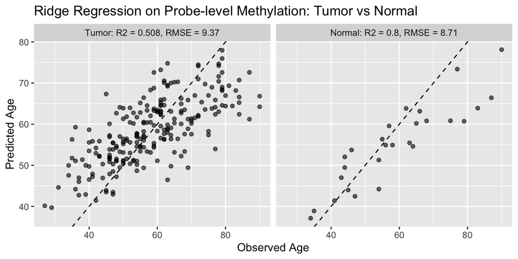

```r
metrics_tumor <- paste0("Tumor: R2 = ", round(r2_tumor, 3),
                        ", RMSE = ", round(rmse_tumor, 2))
metrics_normal <- paste0("Normal: R2 = ", round(r2_normal, 3),
                         ", RMSE = ", round(rmse_normal, 2))
df_pred_probes <- rbind(
  data.frame(Observed = tumor_y_test, Predicted = as.numeric(preds_tumor),
             Tissue = metrics_tumor),
  data.frame(Observed = normal_y_test, Predicted = as.numeric(preds_normal),
             Tissue = metrics_normal)
)
# Order the panels: tumor first, then normal
df_pred_probes$Tissue <- factor(df_pred_probes$Tissue,
                                levels = c(metrics_tumor, metrics_normal))
ggplot(df_pred_probes, aes(x = Observed, y = Predicted)) +
  geom_point(alpha = 0.6) +
  geom_abline(intercept=0, slope=1, linetype="dashed") +
  facet_wrap(~ Tissue) +
  labs(title = "Ridge Regression on Probe-level Methylation: Tumor vs Normal",
    x = "Observed Age",
    y = "Predicted Age")
```

#### 2.5.4.5 Apply a published epigenetic clock

Horvath’s 2013 clock is a penalized regression model, much like the one we just trained. It was fit with elastic net regression on about 8,000 samples from 51 healthy tissue and cell types, and the penalty selected 353 CpG probes out of the 21,000 shared by the arrays used.

What the published model consists of:

- **A coefficient for each of the 353 CpGs.** Each one is the weight applied to that probe’s beta value, exactly like the values in `lin_model$beta` from our ridge model. A positive coefficient means methylation at that site increases with age, a negative one means it decreases.
- **An intercept**, the same as in any linear model.
- **An age transformation.** The clock was not fit to age in years directly. Age was transformed with a log function below 20 years and a linear function above, because methylation changes quickly during development and more slowly in adults. So the linear combination of coefficients and beta values gives transformed age, and we apply the inverse transformation to get back to years.

Applying the clock to a sample is therefore just: intercept plus the sum of each coefficient times its probe’s beta value, then untransform. No training is needed. Our data set includes the 306 clock probes that have complete data here.

```r
clock <- meth_probes$horvath$coefficients
head(clock)
```

|  | probe | coefficient |
| --- | --- | --- |
| 1 | cg00075967 | 0.129336610 |
| 2 | cg00374717 | 0.005017857 |
| 3 | cg00864867 | 1.599764050 |
| 4 | cg00945507 | 0.056852418 |
| 5 | cg01027739 | 0.102862854 |
| 6 | cg01353448 | 0.238560451 |

```r
clock_intercept <- meth_probes$horvath$intercept

# Linear combination of the clock probes for every sample
clock_score <- clock_intercept + probe.data[, clock$probe] %*% clock$coefficient

# Horvath's inverse age transformation
horvath_age <- ifelse(clock_score <= 0, 21 * exp(clock_score) - 1, 21 * clock_score + 20)

df_clock <- data.frame(Observed = probe_meta$AGE,
                       DNAm_Age = as.numeric(horvath_age),
                       Tissue = probe_meta$tissue)
```

Evaluate the clock in each tissue with the same metrics we used for our own models.

```r
clock_metrics <- sapply(c("Tumor", "Normal"), function(tt) {
  d <- df_clock[df_clock$Tissue == tt, ]
  c(R2 = cor(d$Observed, d$DNAm_Age)^2,
    RMSE = sqrt(mean((d$DNAm_Age - d$Observed)^2)))
})
round(clock_metrics, 3)
```

```
##       Tumor Normal
## R2    0.095  0.799
## RMSE 24.987 10.211
```

Plot the clock age against chronological age for each tissue, with the metrics in the panel labels.

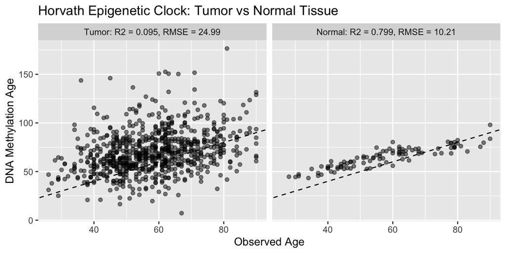

```r
clock_labels <- paste0(colnames(clock_metrics),
                       ": R2 = ", round(clock_metrics["R2", ], 3),
                       ", RMSE = ", round(clock_metrics["RMSE", ], 2))
names(clock_labels) <- colnames(clock_metrics)
df_clock$Panel <- factor(clock_labels[df_clock$Tissue], levels = clock_labels)

ggplot(df_clock, aes(x = Observed, y = DNAm_Age)) +
  geom_point(alpha = 0.5) +
  geom_abline(intercept=0, slope=1, linetype="dashed") +
  facet_wrap(~ Panel) +
  labs(title = "Horvath Epigenetic Clock: Tumor vs Normal Tissue",
    x = "Observed Age",
    y = "DNA Methylation Age")
```

Some points for discussion:

- The clock correlates with age in the normal samples far better than in the tumor samples, even though both were measured on the same array from the same patients.
- Cancer rewires DNA methylation, so tumor methylation reflects the tumor’s biology more than the patient’s age. Our tumor model can only recover a fraction of the signal.
- The clock predicts ages that run high in both tissues, which inflates the RMSE even in normal tissue where the R² is high. Horvath’s clock expects normalized beta values, and we applied it to raw values using only the 306 of its 353 probes with complete data, so a systematic offset is expected. Even so, the relative ordering of samples is preserved in normal tissue.
- Both ridge models used exactly the same features, all 11,884 probes in the filtered data set. No feature selection was done separately for either tissue, and none of the selection used the normal samples’ ages, so the difference between the two panels comes from the tissue and not from the predictors.
- In tumors, our ridge model (R² about 0.5) does far better than the clock (R² about 0.1). Our model was trained on tumor samples, so it learns which sites still track age after cancer has rewired the methylome. The clock was fit only on healthy tissue, and many of its sites are among those that cancer disrupts most. Horvath’s paper reported the same thing: cancer tissue shows large and erratic “age acceleration.” The clock is not a bad model. It is being applied outside the domain it was built for.
- In normal tissue, our ridge model and the clock reach about the same R². In healthy tissue the age signal is strong and shared across people, so both sit near the ceiling that noise and sample size allow. Note that the two numbers are not equally solid: ours comes from only 27 test samples, while the clock’s is computed on all 96 normals with no training at all, which makes it an independent validation. Matching a model trained on this data with one that never saw it is evidence of real generalization.
- The general lesson: a model trained on the target domain wins when the domain shift is large, and a published model should be checked against the tissue and conditions it was built for before trusting its predictions.

**How this compares with the original paper.** Across all of its test data, Horvath’s clock reached a correlation of 0.96 with chronological age and a median error of 3.6 years. Breast tissue was one of the exceptions. The paper reports a correlation of 0.87 with a median error of 13 years in normal adjacent breast tissue, and 0.73 with an error of 8.9 years in breast tissue from women without cancer, and attributes the poor calibration to hormonal effects or cancer field effects. For breast cancer the paper reports a correlation of 0.31, and across 20 cancer types a pooled correlation of only 0.15 with DNA methylation age running ahead of chronological age by 36 years on average. Our results reproduce these figures closely: a correlation of 0.89 in normal adjacent tissue and 0.31 in tumors, despite using raw beta values and 306 of the 353 probes. Part of the match is expected because Horvath’s breast cancer data also came from TCGA. The comparison shows that breast is a difficult tissue for epigenetic age even when healthy, and that both our ridge model and the published clock hit the same ceiling for it, well below what the clock achieves in blood or brain.

## 2.6 Predict survival probability

We are again using the breast cancer data set.

*Load the clinical data and the variance-filtered gene expression data. This is the log-scaled expression data from Day 1, filtered to the top 500 most variable genes.*

```r
brca_cli <- readRDS(url("https://wd.cri.uic.edu/machine_learning/brca_clinical.rds"))
brca.df.var_filt <- readRDS(url(
  "https://wd.cri.uic.edu/machine_learning/brca.df.var_filt.rds"))
```

Data set up steps.

- `DFS_STATUS` is the status of the tumor.
- `DFS_MONTHS` is the follow-up time.

```r
# Get samples with complete cases of DFS_MONTHS and DFS_STATUS from the clinical data
keep <- complete.cases(brca_cli$DFS_MONTHS,
                       brca_cli$DFS_STATUS) & brca_cli$DFS_MONTHS >= 0
DFS_MONTHS_clean <- brca_cli$DFS_MONTHS[keep]
summary(DFS_MONTHS_clean)
```

```
##    Min. 1st Qu.  Median    Mean 3rd Qu.    Max.
##    0.00   14.16   24.57   37.07   50.27  281.08
```

```r
DFS_STATUS_clean <- brca_cli$DFS_STATUS[keep]
table(DFS_STATUS_clean)
```

```
## DFS_STATUS_clean
##         0:DiseaseFree 1:Recurred/Progressed
##                   890                   113
```

```r
brca.clean.df <- brca.df.var_filt[keep, ]
```

Adjust for 0-month censored patients.

- Cox proportional analysis expects all the disease free survival times to be positive because there is a log(time) in the calculation.
- If DFS_MONTHS = 0 and status = 0 (DiseaseFree). It means no follow-up time was recorded. These are basically useless so we remove them.
- If DFS_MONTHS = 0 and status = 1 (Recurred/Progressed). This implies recurrence was recorded at the baseline date. Often treated as valid, but for modeling stability we usually add a tiny offset (e.g., 0.001 months) instead of zero.

```r
library(survival)
library(survcomp)
library(survminer)

# Adjust 0 times
DFS_MONTHS_clean[DFS_MONTHS_clean == 0 &
                   DFS_STATUS_clean == "1:Recurred/Progressed"] <- 0.001

# Drop 0-month censored patients
keep2 <- !(DFS_MONTHS_clean == 0 & DFS_STATUS_clean == "0:DiseaseFree")

DFS_MONTHS_clean <- DFS_MONTHS_clean[keep2]
DFS_STATUS_clean <- DFS_STATUS_clean[keep2]
brca.clean.df <- brca.clean.df[keep2, ]

# Build survival object
status <- ifelse(DFS_STATUS_clean == "1:Recurred/Progressed", 1, 0)
head(status)
```

```
## [1] 1 0 0 0 0 0
```

```r
y <- Surv(time = DFS_MONTHS_clean, event = status)
head(y)
```

```
## [1] 12.71  10.91+ 11.33+ 11.27+ 10.41+ 12.32+
```

```r
x <- as.matrix(brca.clean.df)
```

Fit the Cox regression model.

- Note that this step is computationally intensive. In the interest of time we will make a smaller subset of the data so this runs faster.
- You can try this exercise without the subsampling on your own.

```r
library(glmnet)

set.seed(123)
# subset data for a faster processing time
subsample <- sample(1:length(y),400)
x <- x[subsample, ]
y <- y[subsample]
DFS_MONTHS_clean <- DFS_MONTHS_clean[subsample]
status <- status[subsample]
# fit the model
coxfit <- cv.glmnet(
  x,
  y,
  family = "cox",
  alpha = 1,              # LASSO
  nfolds = 5              # 5-fold CV
)
coxfit
```

```
##
## Call:  cv.glmnet(x = x, y = y, nfolds = 5, family = "cox", alpha = 1)
##
## Measure: Partial Likelihood Deviance
##
##      Lambda Index Measure     SE Nonzero
## min 0.05209     6   1.497 0.1366       1
## 1se 0.06573     1   1.503 0.1382       0
```

```r
# Best lambda
best_lambda <- coxfit$lambda.min

# Refit model at best lambda
coxfinal <- glmnet(x,
                   y,
                   family = "cox",
                   alpha = 1,
                   lambda = best_lambda)

# Get nonzero coefficients
cox_selected_genes <- rownames(coef(coxfinal))[coef(coxfinal)[,1] != 0]
length(cox_selected_genes)
```

```
## [1] 1
```

```r
cox_selected_genes
```

```
## [1] "PPP4R4"
```

```r
# Predicted risk score
risk_scores <- predict(coxfinal, newx = x, type = "link")

cindex <- concordance.index(
  x = risk_scores,
  surv.time = DFS_MONTHS_clean,
  surv.event = status
)

cindex$c.index
```

```
## [1] 0.6952654
```

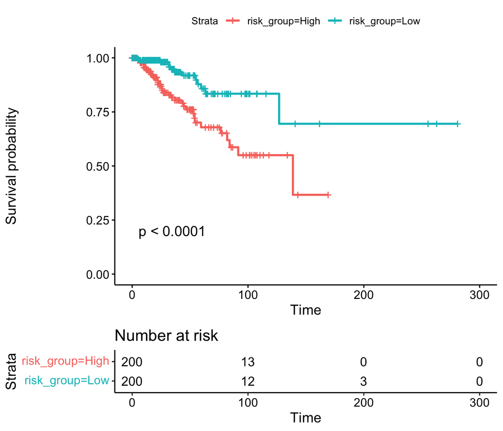

```r
# Visualize Kaplan-Meier curves
risk_group <- ifelse(risk_scores > median(risk_scores), "High", "Low")
df.km <- data.frame(
  DFS_MONTHS = DFS_MONTHS_clean,
  status = status,
  risk_group = risk_group
)
fit_km <- survfit(Surv(DFS_MONTHS, status) ~ risk_group, data = df.km)
ggsurvplot(fit_km, data = df.km, pval = TRUE, risk.table = TRUE, risk.table.height = 0.25)
```

# 3 Take-home exercises

## 3.1 Unbalanced model training (take home)

### 3.1.1 Create unbalanced dataset

```r
library(tidyverse)

# Use complete set of ductal and lobular samples
ductal.samples.all <- brca_cli.ductal$sampleId
ductal.exp.all <- all_brca_RNA.log2.filtered[,ductal.samples.all]
lobular.samples.all <- brca_cli.lobular$sampleId
lobular.exp.all <- all_brca_RNA.log2.filtered[,lobular.samples.all]

# Combine ductal and lobular expression datasets and convert to matrix
expr_combined.all <- cbind(ductal.exp.all, lobular.exp.all)
n_ductal  <- ncol(ductal.exp.all)
n_lobular <- ncol(lobular.exp.all)
labels.all <- c(rep("Ductal", n_ductal), rep("Lobular", n_lobular))
table(labels.all)
```

```
## labels.all
##  Ductal Lobular
##     812     206
```

```r
# Build data.frame for modeling: samples x genes
df.all <- as.data.frame(t(expr_combined.all))  # rows = samples, cols = genes
df.all <- tibble::rownames_to_column(df.all, var = "sample_id")
df.all$class <- factor(labels.all, levels = c("Ductal","Lobular"))
colnames(df.all) <- make.names(colnames(df.all))
```

### 3.1.2 Make a stratified training and testing set

```r
library(caret)
library(dplyr)

set.seed(123)  # for reproducibility

# Make stratified split (70% train, 30% test)
# Note: When you pass a factor or outcome vector, createDataPartition()
# automatically does stratified sampling

train_index <- createDataPartition(df.all$class, p = 0.7, list = FALSE)

train_data <- df.all[train_index, ]
test_data  <- df.all[-train_index, ]

# For convenience, create x and y
x_train.all <- train_data %>% select(-sample_id, -class)
y_train.all <- train_data$class
x_test.all  <- test_data %>% select(-sample_id, -class)
y_test.all  <- test_data$class

# Check class distribution
prop.table(table(df.all$class))       # overall
```

```
##
##    Ductal   Lobular
## 0.7976424 0.2023576
```

```r
prop.table(table(train_data$class))   # training
```

```
##
##    Ductal   Lobular
## 0.7969188 0.2030812
```

```r
prop.table(table(test_data$class))    # testing
```

```
##
##    Ductal   Lobular
## 0.7993421 0.2006579
```

### 3.1.3 Feature elimination and RFE with logistic regression

```r
library(caret)
library(ggplot2)

# T-test to rank remaining features
ttest_ranks.all <- apply(x_train.all, 2, function(g) {
  t.test(g ~ y_train.all)$statistic
})
ttest_ranks.all <- sort(abs(ttest_ranks.all), decreasing = TRUE)

# Pick the top 100 genes
top_ttest_genes.all <- names(ttest_ranks.all)[1:100]
df_ttest_filtered.all <- x_train.all[, top_ttest_genes.all]

# Number of features to be retained in the updated model
sizes <- c(5, 10, 15, 20, 25, 30, 35, 40, 45, 50)

# Perform RFE
set.seed(123)
rfe_ctrl <- rfeControl(functions = lrFuncs,
                   method = "cv", # cross validation
                   number = 10) # number of folds
rfe_results_all <- rfe(
  x = df_ttest_filtered.all,
  y = y_train.all,
  sizes = sizes,   # candidate numbers of features
  rfeControl = rfe_ctrl
)

best_rfe_feats_all<- predictors(rfe_results_all)
best_rfe_feats_all
```

```
##  [1] "CYP21A2" "FXYD1"   "GMPS"    "PGM5"    "TNXB"    "ADAM33"  "CAVIN2"
##  [8] "PNPLA2"  "F10"     "CDH1"
```

### 3.1.4 Calculate F1 statistics on test set

```r
library(caret)
library(MLmetrics)

# Subset training and testing data to the selected features
Xtr.all <- x_train.all[, best_rfe_feats_all]
Xte.all  <- x_test.all[, best_rfe_feats_all]

# Make training control function
lr_ctrl_F1 <- trainControl(
  method = "cv",
  number = 10,
  classProbs = TRUE,
  savePredictions = "final",
  summaryFunction = function(data, lev = NULL, model = NULL) {
    f1 <- F1_Score(y_pred = data$pred, y_true = data$obs, positive = lev[2])
    c(F1 = f1)
    }
  )

# Train logistic regression with 10-fold CV
set.seed(123)
lr_model2 <- train(
  x = Xtr.all,
  y = y_train.all,
  method = "glm",
  family = "binomial",
  metric = "F1",
  trControl = lr_ctrl_F1
)

# Predict on the test set
y_pred <- predict(lr_model2, newdata = Xte.all)

# Test-set F1 score
f1_test <- F1_Score(y_pred, y_test.all, positive = "Lobular")
f1_test
```

```
## [1] 0.8070175
```

```r
# Cross-validation predictions
lr2_train_preds <- lr_model2$pred$pred
lr2_train_obs <- lr_model2$pred$obs

lr_model2_cm_cv <- confusionMatrix(lr2_train_preds, lr2_train_obs, positive = "Lobular")
lr_model2_cm_cv
```

```
## Confusion Matrix and Statistics
##
##           Reference
## Prediction Ductal Lobular
##    Ductal     540      45
##    Lobular     29     100
##
##                Accuracy : 0.8964
##                  95% CI : (0.8716, 0.9177)
##     No Information Rate : 0.7969
##     P-Value [Acc > NIR] : 7.622e-13
##
##                   Kappa : 0.6661
##
##  Mcnemar's Test P-Value : 0.08121
##
##             Sensitivity : 0.6897
##             Specificity : 0.9490
##          Pos Pred Value : 0.7752
##          Neg Pred Value : 0.9231
##              Prevalence : 0.2031
##          Detection Rate : 0.1401
##    Detection Prevalence : 0.1807
##       Balanced Accuracy : 0.8193
##
##        'Positive' Class : Lobular
##
```

```r
lr_model2_cm_test <- confusionMatrix(y_pred, y_test.all, positive = "Lobular")
lr_model2_cm_test
```

```
## Confusion Matrix and Statistics
##
##           Reference
## Prediction Ductal Lobular
##    Ductal     236      15
##    Lobular      7      46
##
##                Accuracy : 0.9276
##                  95% CI : (0.8925, 0.9541)
##     No Information Rate : 0.7993
##     P-Value [Acc > NIR] : 4.13e-10
##
##                   Kappa : 0.7628
##
##  Mcnemar's Test P-Value : 0.1356
##
##             Sensitivity : 0.7541
##             Specificity : 0.9712
##          Pos Pred Value : 0.8679
##          Neg Pred Value : 0.9402
##              Prevalence : 0.2007
##          Detection Rate : 0.1513
##    Detection Prevalence : 0.1743
##       Balanced Accuracy : 0.8626
##
##        'Positive' Class : Lobular
##
```

## 3.2 Random Forest regression (take home)

We will fit Random Forest regression models for age to the probe-level DNA methylation data used in the Ridge regression exercise, for the tumor samples and for the adjacent normal samples, and compare them to the Ridge results.

You can similarly fit an XGBoost regression model with appropriate changes to the parameters in this exercise.

*Read in the filtered probe-level data set (the same file used in the Ridge regression exercise).*

```r
library(caret)
library(ggplot2)
meth_probes <- readRDS(url(
  "https://wd.cri.uic.edu/machine_learning/brca_methylation_hm450_probes.rds"))
probe.data <- t(meth_probes$beta)
probe_meta <- meth_probes$samples
dim(probe.data)
```

```
## [1]   875 11884
```

```r
table(probe_meta$tissue)
```

```
##
## Normal  Tumor
##     96    779
```

### 3.2.1 Random forest in tumor samples

Make the same training and test split as in the Ridge exercise.

```r
is_tumor <- probe_meta$tissue == "Tumor"
tumor.data <- probe.data[is_tumor, ]
tumor_age <- probe_meta$AGE[is_tumor]

set.seed(123)
tumor_idx <- createDataPartition(tumor_age, p = 0.7, list = F)
tumor_x_train <- tumor.data[tumor_idx, ]
tumor_y_train <- tumor_age[tumor_idx]
tumor_x_test <- tumor.data[-tumor_idx, ]
tumor_y_test <- tumor_age[-tumor_idx]
```

Train the model. With almost 12,000 features, the default `mtry` for regression (one third of the features) is large, so we try two smaller values. Each tree is grown on a random subset of `mtry` probes at every split.

- Note that this step takes several minutes: 5-fold CV with two `mtry` values means 10 forests plus the final fit, each with 300 trees.

```r
rf_reg_ctrl <- trainControl(
  method = "cv",
  number = 5,
  savePredictions = "final"
)
set.seed(123)
rf_tumor_model <- train(
  x = tumor_x_train,
  y = tumor_y_train,
  method = "rf",
  ntree = 300,
  tuneGrid = expand.grid(mtry = c(100, 1000)),
  trControl = rf_reg_ctrl
)
rf_tumor_model
```

```
## Random Forest
##
##   547 samples
## 11884 predictors
##
## No pre-processing
## Resampling: Cross-Validated (5 fold)
## Summary of sample sizes: 438, 439, 436, 437, 438
## Resampling results across tuning parameters:
##
##   mtry  RMSE      Rsquared   MAE
##    100  11.50980  0.2827851  9.292170
##   1000  10.99726  0.3740913  8.841101
##
## RMSE was used to select the optimal model using the smallest value.
## The final value used for the model was mtry = 1000.
```

Evaluate on the test set.

```r
preds_rf_tumor <- predict(rf_tumor_model, newdata = tumor_x_test)
r2_rf_tumor <- cor(preds_rf_tumor, tumor_y_test)^2
r2_rf_tumor
```

```
## [1] 0.348953
```

```r
rmse_rf_tumor <- sqrt(mean((preds_rf_tumor - tumor_y_test)^2))
rmse_rf_tumor
```

```
## [1] 11.07846
```

### 3.2.2 Random forest in adjacent normal samples

Repeat for the normal samples. This runs much faster since there are only 96 samples.

```r
is_normal <- probe_meta$tissue == "Normal"
normal.data <- probe.data[is_normal, ]
normal_age <- probe_meta$AGE[is_normal]

set.seed(123)
normal_idx <- createDataPartition(normal_age, p = 0.7, list = F)
normal_x_train <- normal.data[normal_idx, ]
normal_y_train <- normal_age[normal_idx]
normal_x_test <- normal.data[-normal_idx, ]
normal_y_test <- normal_age[-normal_idx]

set.seed(123)
rf_normal_model <- train(
  x = normal_x_train,
  y = normal_y_train,
  method = "rf",
  ntree = 300,
  tuneGrid = expand.grid(mtry = c(100, 1000)),
  trControl = rf_reg_ctrl
)
rf_normal_model
```

```
## Random Forest
##
##    69 samples
## 11884 predictors
##
## No pre-processing
## Resampling: Cross-Validated (5 fold)
## Summary of sample sizes: 56, 56, 55, 56, 53
## Resampling results across tuning parameters:
##
##   mtry  RMSE      Rsquared   MAE
##    100  12.46984  0.4570894  10.24714
##   1000  10.69705  0.6136899   8.84581
##
## RMSE was used to select the optimal model using the smallest value.
## The final value used for the model was mtry = 1000.
```

```r
preds_rf_normal <- predict(rf_normal_model, newdata = normal_x_test)
r2_rf_normal <- cor(preds_rf_normal, normal_y_test)^2
r2_rf_normal
```

```
## [1] 0.8071707
```

```r
rmse_rf_normal <- sqrt(mean((preds_rf_normal - normal_y_test)^2))
rmse_rf_normal
```

```
## [1] 9.206369
```

### 3.2.3 Compare the two tissues

Plot the two random forest regressions side by side, as we did for Ridge regression.

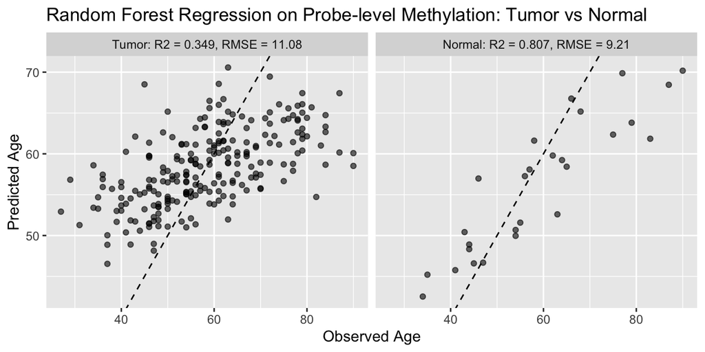

```r
metrics_rf_tumor <- paste0("Tumor: R2 = ", round(r2_rf_tumor, 3),
                           ", RMSE = ", round(rmse_rf_tumor, 2))
metrics_rf_normal <- paste0("Normal: R2 = ", round(r2_rf_normal, 3),
                            ", RMSE = ", round(rmse_rf_normal, 2))
df_pred_rf <- rbind(
  data.frame(Observed = tumor_y_test, Predicted = as.numeric(preds_rf_tumor),
             Tissue = metrics_rf_tumor),
  data.frame(Observed = normal_y_test, Predicted = as.numeric(preds_rf_normal),
             Tissue = metrics_rf_normal)
)
df_pred_rf$Tissue <- factor(df_pred_rf$Tissue,
                            levels = c(metrics_rf_tumor, metrics_rf_normal))
ggplot(df_pred_rf, aes(x = Observed, y = Predicted)) +
  geom_point(alpha = 0.6) +
  geom_abline(intercept=0, slope=1, linetype="dashed") +
  facet_wrap(~ Tissue) +
  labs(title = "Random Forest Regression on Probe-level Methylation: Tumor vs Normal",
    x = "Observed Age",
    y = "Predicted Age")
```

Compare these results with the Ridge regression from Day 2, which used exactly the same samples, split, and features.

- In tumors, the random forest does worse than Ridge regression. Age-related methylation change is a small, additive shift spread across many sites, which is exactly what a linear model with many correlated predictors captures well. Trees have to find that signal one split at a time, and with 12,000 features and a few hundred samples, most splits land on tumor-related variation instead.
- In normal tissue, the two methods perform about the same. When the signal is strong, most reasonable models reach the same ceiling.
- Notice that the random forest predictions span a narrower range than the observed ages, especially in tumors. Each prediction is an average over many trees, and a tree can never predict outside the range of ages it saw in training, so tree ensembles pull predictions toward the mean.
- The random forest reports its own cross-validation R² in the `train` output. Compare it with the test-set value, as we did for Ridge.